# 2024-08-14_Hypothesis1_MultilevelModel

2025-01-19

**Attentional Biases in OCD**  
**Script Part II / ?**  
**Date: 24.07.2024**  
**Version: Version 2**

# Description

This is the main analysis file of hypothesis 1 of the 044_EYE project on Attentional Biases in OCD. This script includes the multilevel model that aims to test the main hypotheses. Furthermore, this script contains tests of the assumptions of multilevel models as well as descriptive plots.

## Hypotheses

### 1.) Vigilance Bias:

Patients with **OCD** and patients with **spider phobia** attend to **idiosyncratic disorder-relevant material faster** than they do to **neutral** or **negative** material (vigilance bias), as indicated by the entry time to the corresponding region of interest. **Healthy participants** will **not show a bias** towards disorder-relevant stimuli compared to negative or neutral stimuli.

### 2.) Maintenance Bias:

**a.**  
Patients with **OCD** look at **idiosyncratic OCD-relevant material longer** compared to **neutral** or **negative** material (maintenance bias). **b.**  
Patients with **OCD** will show a **more pronounced maintenance bias** compared to **healthy** participants and, with regard to **idiosyncratic disorder-specific material**, compared to patients with **spider phobia**.

### 3.) Attentional Control

#### Subjective Measure

**a.**  
In patients with **OCD** and patients with **spider phobia**, there will be a **positive association** between **vigilance bias** and **attentional control** as measured by the self-report questionnaire (Attentional Control Scale). This means the lower the attentional control, the faster patients with OCD or spider phobia will look at OCD-relevant or spider-relevant material, respectively, compared to negative or neutral material. **b.**  
In patients with **OCD**, there will be a **negative association** between the **maintenance bias** and **attentional control** as measured by the self-report questionnaire (Attentional Control Scale). This means the lower the attentional control, the longer patients will look at idiosyncratic OCD-relevant material compared to negative or neutral material.

####Objective Measure **c.** In patients with **OCD** and patients with **spider phobia**, there will be a positive association between **vigilance bias** and **attentional control** as measured by the objective measure (AX-CPT). **d.** In patients with **OCD**, there will be a **negative association** between the **maintenance bias** and **attentional control** as measured by the objective measure (AX-CPT).

### 4.) Stress

The induction of **stress** significantly increases the **maintenance bias** in patients with **OCD** (state-level). This means that patients with OCD will **look at OCD-relevant material for longer** after the stress induction than before the stress induction.

**Install Packages**

**Load Packages**

**Define the Colour Scheme**

# Install Julia

```r
library(JuliaCall)
options(JULIA_HOME = "/Applications/Julia-1.11.app/Contents/Resources/julia/bin") # need to define the path for my Mac to resolve bug
j = julia_setup(installJulia = TRUE)
```

```
## Julia version 1.11.0 at location /Applications/Julia-1.11.app/Contents/Resources/julia/bin will be used.
```

```
## Loading setup script for JuliaCall...
```

```
## Finish loading setup script for JuliaCall.
```

## Install Julia Packages

```
## "lmerTest::lmer"
```

# Load Data

```r
# data_dwelltime = read.csv("../data/data_dwelltime_OA.csv")
# data_entrytime = read.csv("../data/data_entrytime_OA.csv")
data_dwelltime = read.csv("/Volumes/109-psy-kp-study/044_EYE/06_Results/02_Hauptstudie/FilesAnalysis/data_dwelltime_OA.csv")
data_entrytime = read.csv("/Volumes/109-psy-kp-study/044_EYE/06_Results/02_Hauptstudie/FilesAnalysis/data_entrytime_OA.csv")

# Ensure participant IDs match between entry-time and dwell-time datasets
data_entrytime$participant = data_dwelltime$participant

# Set reaction time (rt) for the left stimulus using the first entry time to the lower-left position
data_entrytime$rt = data_entrytime$first_entry_time_left

# For trials where the right stimulus was fixated first, update reaction time with the first entry time to the upper-right position
ix_right = is.na(data_entrytime$first_entry_time_left)
data_entrytime$rt[ix_right] = data_entrytime$first_entry_time_right[ix_right]

# Determine which stimulus (lower-left or upper-right) was fixated first and store the corresponding stimulus ID (2 = left, 1 = right -> recoded to 0 = left, 1 = right)
data_entrytime$response = data_entrytime$first_entry_ID_left
data_entrytime$response[ix_right] = data_entrytime$first_entry_ID_right[ix_right]
data_entrytime <- data_entrytime %>%
  dplyr::mutate(response = ifelse(response == 2, 0,
                           ifelse(response == 1, 1, NA)))

# Set contrasts for stimuli attributes based on their positions (lower-left: -1, upper-right: +1)
data_entrytime$ocd_left = data_entrytime$ocd_relevant_left == 1
data_entrytime$ocd_right = data_entrytime$ocd_relevant_right == 1

data_entrytime$pho_left = data_entrytime$spider_relevant_left == 1
data_entrytime$pho_right = data_entrytime$spider_relevant_right == 1

data_entrytime$neg_left = data_entrytime$negative_left == 1
data_entrytime$neg_right = data_entrytime$negative_right == 1

data_entrytime$neu_left = data_entrytime$neutral_left == 1
data_entrytime$neu_right = data_entrytime$neutral_right == 1

# Identify which direction the participant looked first (ir = upper-right, il = lower-left)
data_entrytime$looked_right = is.na(data_entrytime$first_entry_ID_left)
ir = data_entrytime$looked_right
il = !data_entrytime$looked_right

# Initialize columns to store the type of stimulus looked at and not looked at
data_entrytime$looked_at = 'neutral'
data_entrytime$not_looked_at = 'neutral'

# Set 'looked_at' based on whether the first fixation was on the lower-left or upper-right stimulus with specific attributes
ix = (il & data_entrytime$pho_left) | (ir & data_entrytime$pho_right)
data_entrytime$looked_at[ix] = "pho"

ix = (il & data_entrytime$ocd_left) | (ir & data_entrytime$ocd_right)
data_entrytime$looked_at[ix] = "ocd"

ix = (il & data_entrytime$neg_left) | (ir & data_entrytime$neg_right)
data_entrytime$looked_at[ix] = "neg"

# Set 'not_looked_at' based on the attribute of the stimulus that was not fixated on first
ix = (ir & data_entrytime$pho_left) | (il & data_entrytime$pho_right)
data_entrytime$not_looked_at[ix] = "pho"

ix = (ir & data_entrytime$ocd_left) | (il & data_entrytime$ocd_right)
data_entrytime$not_looked_at[ix] = "ocd"

ix = (ir & data_entrytime$neg_left) | (il & data_entrytime$neg_right)
data_entrytime$not_looked_at[ix] = "neg"
```

# Hypothesis 1: Maintenance Bias

**From Complex to Simple Multilevel Models** ## Hypothesis 1: Create Models

```r
#j $assign("form", formula(mlm_dwelltime))
j$assign("jl_data_dwelltime", data_dwelltime)
j$assign("jl_data_entrytime", data_entrytime)
julia_command("jl_data_entrytime.response .= jl_data_entrytime.response .-1")
```

```
## 25608-element Vector{Float64}:
##  -1.0
##  -1.0
##   0.0
##  -1.0
##   0.0
##  -1.0
##   0.0
##   0.0
##   0.0
##  -1.0
##   ⋮
##  -1.0
##  -1.0
##   0.0
##  -1.0
##  -1.0
##  -1.0
##  -1.0
##  -1.0
##  -1.0
```

```r
julia_command("using MixedModels")
```

```r
julia_command("using JellyMe4")
```

```r
julia_command("using Pkg")
```

```r
julia_command('Pkg.add("NLopt")')
```

```r
julia_command("using NLopt")
```

```julia
c_dwelltime = Dict(:group=>DummyCoding(;base="healthy"))
```

```
## Dict{Symbol, DummyCoding} with 1 entry:
##   :group => DummyCoding("healthy", nothing)
```

```r
# # Model 1: Most Complex Model
# julia_command("h1_fm_complex = @formula(dwell_diff ~ group + stim_ocd + stim_pho + stim_neg + group&stim_ocd + group&stim_pho + group&stim_neg +
#               (1 + stim_ocd + stim_pho + stim_neg | triplet)+
#               (1 + stim_ocd + stim_pho + stim_neg | participant) +
#               (1 + group | picture_pair_countingindex))")
#
# # Model 2a: Triplet ZeroCorr
# julia_command("h1_fm_triplet_zerocorr = @formula(dwell_diff ~ group + stim_ocd + stim_pho + stim_neg + group&stim_ocd + group&stim_pho + group&stim_neg +
#               zerocorr(1 + stim_ocd + stim_pho + stim_neg | triplet)+
#               (1 + stim_ocd + stim_pho + stim_neg | participant) +
#               (1 + group | picture_pair_countingindex))")
#
# # Model 2b: Triplet and Participant ZeroCorr
# julia_command("h1_fm_triplet_id_zerocorr = @formula(dwell_diff ~ group + stim_ocd + stim_pho + stim_neg + group&stim_ocd + group&stim_pho + group&stim_neg +
#               zerocorr(1 + stim_ocd + stim_pho + stim_neg | triplet)+
#               zerocorr(1 + stim_ocd + stim_pho + stim_neg | participant) +
#               (1 + group | picture_pair_countingindex))")
#
# # Model 2c: Triplet, Participant and Item Effect ZeroCorr
# julia_command("h1_fm_triplet_id_item_zerocorr = @formula(dwell_diff ~ group + stim_ocd + stim_pho + stim_neg + group&stim_ocd + group&stim_pho + group&stim_neg +
#               zerocorr(1 + stim_ocd + stim_pho + stim_neg | triplet)+
#               zerocorr(1 + stim_ocd + stim_pho + stim_neg | participant) +
#               zerocorr(1 + group | picture_pair_countingindex))")
#
# # Model 3a: Exclude Participant
# julia_command("h1_fm_excl_id = @formula(dwell_diff ~ group + stim_ocd + stim_pho + stim_neg + group&stim_ocd + group&stim_pho + group&stim_neg +
#               (1 + stim_ocd + stim_pho + stim_neg | triplet)+
#               (1 + group | picture_pair_countingindex))")
#
# # Model 3b: Exclude Triplet
# julia_command("h1_fm_excl_triplet = @formula(dwell_diff ~ group + stim_ocd + stim_pho + stim_neg + group&stim_ocd + group&stim_pho + group&stim_neg +
#               (1 + stim_ocd + stim_pho + stim_neg | participant)+
#               (1 + group | picture_pair_countingindex))")
#
# # Model 3c: Exclude Item
# julia_command("h1_fm_excl_item  = @formula(dwell_diff ~ group + stim_ocd + stim_pho + stim_neg + group&stim_ocd + group&stim_pho + group&stim_neg +
#               (1 + stim_ocd + stim_pho + stim_neg | triplet)+
#               (1 + stim_ocd + stim_pho + stim_neg | participant))")
#
# # Model 4a: Exclude Participant and Triplet
# julia_command("h1_fm_excl_triplet_id = @formula(dwell_diff ~ group + stim_ocd + stim_pho + stim_neg + group&stim_ocd + group&stim_pho + group&stim_neg +
#               (1 + group | picture_pair_countingindex))")

# Model 4b: Exclude Triplet and Item
julia_command("h1_fm_excl_triplet_item = @formula(dwell_diff ~ group + stim_ocd + stim_pho + stim_neg + group&stim_ocd + group&stim_pho + group&stim_neg +
              (1 + stim_ocd + stim_pho + stim_neg | participant))")
```

```
## FormulaTerm
## Response:
##   dwell_diff(unknown)
## Predictors:
##   group(unknown)
##   stim_ocd(unknown)
##   stim_pho(unknown)
##   stim_neg(unknown)
##   group(unknown) & stim_ocd(unknown)
##   group(unknown) & stim_pho(unknown)
##   group(unknown) & stim_neg(unknown)
##   (stim_ocd,stim_pho,stim_neg,participant)->(1 + stim_ocd + stim_pho + stim_neg) | participant
```

```r
# # Model 4c: Exclude Participant and Item
# julia_command("h1_fm_excl_id_item = @formula(dwell_diff ~ group + stim_ocd + stim_pho + stim_neg + group&stim_ocd + group&stim_pho + group&stim_neg +
#             (1 + stim_ocd + stim_pho + stim_neg | triplet))")
```

## Hypothesis 1: Run Models

```r
# # Model 1
# julia_command("h1_fm_complex = fit(LinearMixedModel, h1_fm_complex, jl_data_dwelltime)")
#
# # Models 2: Zero Correlation
# julia_command("h1_fm_trip_zc = fit(LinearMixedModel, h1_fm_triplet_zerocorr, jl_data_dwelltime)")
# julia_command("h1_fm_trip_id_zc = fit(LinearMixedModel, h1_fm_triplet_id_zerocorr, jl_data_dwelltime)")
# julia_command("h1_fm_trip_id_item_zc = fit(LinearMixedModel, h1_fm_triplet_id_item_zerocorr, jl_data_dwelltime)")
#
# # Models 3: Exclude One Random Effect
# julia_command("h1_fm_excl_id = fit(LinearMixedModel, h1_fm_excl_id, jl_data_dwelltime)")
# julia_command("h1_fm_excl_triplet = fit(LinearMixedModel, h1_fm_excl_triplet, jl_data_dwelltime)")
# julia_command("h1_fm_excl_item = fit(LinearMixedModel, h1_fm_excl_item, jl_data_dwelltime)")

# Models 4: Exclude Two Random Effects
# julia_command("h1_fm_excl_triplet_id = fit(LinearMixedModel, h1_fm_excl_triplet_id, jl_data_dwelltime)")
julia_command("h1_fm_excl_triplet_item = fit(LinearMixedModel, h1_fm_excl_triplet_item, jl_data_dwelltime; contrasts=c_dwelltime)")
```

```
## Linear mixed model fit by maximum likelihood
##  dwell_diff ~ 1 + group + stim_ocd + stim_pho + stim_neg + group & stim_ocd + group & stim_pho + group & stim_neg + (1 + stim_ocd + stim_pho + stim_neg | participant)
##     logLik     -2 logLik       AIC         AICc          BIC
##  -225395.5121  450791.0242  450837.0242  450837.0673  451024.4894
##
## Variance components:
##                Column     Variance  Std.Dev.   Corr.
## participant (Intercept)    93055.802  305.050
##             stim_ocd      115653.292  340.078 -0.07
##             stim_pho      433817.921  658.649 +0.06 -0.04
##             stim_neg      396223.660  629.463 +0.06 +0.29 +0.11
## Residual                 2455518.613 1567.009
##  Number of obs: 25608; levels of grouping factors: 165
##
##   Fixed-effects parameters:
## ──────────────────────────────────────────────────────────────────
##                                Coef.  Std. Error       z  Pr(>|z|)
## ──────────────────────────────────────────────────────────────────
## (Intercept)                 124.486      41.5391    3.00    0.0027
## group: ocd                  -74.2525     62.0095   -1.20    0.2311
## group: spider               -32.1335     62.7326   -0.51    0.6085
## stim_ocd                     56.2165     57.1183    0.98    0.3250
## stim_pho                   -225.286      85.4011   -2.64    0.0083
## stim_neg                     47.1        84.2647    0.56    0.5762
## group: ocd & stim_ocd       -66.5318     84.4183   -0.79    0.4306
## group: spider & stim_ocd     21.6317     85.8098    0.25    0.8010
## group: ocd & stim_pho      -353.086     127.989    -2.76    0.0058
## group: spider & stim_pho  -1407.62      131.271   -10.72    <1e-26
## group: ocd & stim_neg      -272.335     124.534    -2.19    0.0288
## group: spider & stim_neg   -410.289     127.373    -3.22    0.0013
## ──────────────────────────────────────────────────────────────────
```

```r
# julia_command("h1_fm_excl_id_item = fit(LinearMixedModel, h1_fm_excl_id_item, jl_data_dwelltime)")
```

## Hypothesis 1: Translate Models to R

```r
# Model 1: Complex Model
# h1_fm_complex <- julia_eval("robject(:lmerMod, Tuple([h1_fm_complex,jl_data_dwelltime]));",need_return="R")

# Models 2: Zero Correlation
# h1_fm_trip_zc <- julia_eval("robject(:lmerMod, Tuple([h1_fm_trip_zc,jl_data_dwelltime]));",need_return="R")
# h1_fm_trip_id_zc <- julia_eval("robject(:lmerMod, Tuple([h1_fm_trip_id_zc,jl_data_dwelltime]));",need_return="R")
# h1_fm_trip_id_item_zc <- julia_eval("robject(:lmerMod, Tuple([h1_fm_trip_id_item_zc,jl_data_dwelltime]));",need_return="R") # error happens in Julia: Error in getStart(start, rho$pp) : incorrect number of theta components (!=15)

# Models 3: Exclude One Random Effect
# h1_fm_excl_id <- julia_eval("robject(:lmerMod, Tuple([h1_fm_excl_id,jl_data_dwelltime]));",need_return="R")
# h1_fm_excl_triplet <- julia_eval("robject(:lmerMod, Tuple([h1_fm_excl_triplet,jl_data_dwelltime]));",need_return="R")
# h1_fm_excl_item <- julia_eval("robject(:lmerMod, Tuple([h1_fm_excl_item,jl_data_dwelltime]));",need_return="R")

# Models 4: Exclude Two Random Effects
# h1_fm_excl_triplet_id <- julia_eval("robject(:lmerMod, Tuple([h1_fm_excl_triplet_id,jl_data_dwelltime]));",need_return="R")
h1_fm_excl_triplet_item <- julia_eval("robject(:lmerMod, Tuple([h1_fm_excl_triplet_item,jl_data_dwelltime]));",need_return="R")
# h1_fm_excl_id_item <- julia_eval("robject(:lmerMod, Tuple([h1_fm_excl_id_item,jl_data_dwelltime]));",need_return="R")
```

### Hypothesis 1: Evaluate Best Fitting Model

```r
# h1_fm_complex, h1_fm_trip_id_item_zc,
# anova(h1_fm_excl_id, h1_fm_trip_zc, h1_fm_trip_id_zc, h1_fm_excl_triplet, h1_fm_excl_item, h1_fm_excl_triplet_id, h1_fm_excl_triplet_item, h1_fm_excl_id_item)

# best: h1_fm_excl_triplet_item

summary(h1_fm_excl_triplet_item)
```

```
## Linear mixed model fit by maximum likelihood . t-tests use Satterthwaite's
##   method [lmerModLmerTest]
## Formula:
## dwell_diff ~ 1 + group + stim_ocd + stim_pho + stim_neg + group:stim_ocd +
##     group:stim_pho + group:stim_neg + (1 + stim_ocd + stim_pho +
##     stim_neg | participant)
##    Data: jellyme4_data
## Control:
## lme4::lmerControl(optCtrl = list(maxeval = 1), optimizer = "nloptwrap",
##     calc.derivs = FALSE, check.nobs.vs.rankZ = "warning", check.nobs.vs.nlev = "warning",
##     check.nlev.gtreq.5 = "ignore", check.nlev.gtr.1 = "warning",
##     check.nobs.vs.nRE = "warning", check.rankX = "message+drop.cols",
##     check.scaleX = "warning", check.formula.LHS = "stop")
##
##       AIC       BIC    logLik  deviance  df.resid
##  450837.0  451024.5 -225395.5  450791.0     25585
##
## Scaled residuals:
##     Min      1Q  Median      3Q     Max
## -4.0714 -0.6358  0.0057  0.6311  4.4302
##
## Random effects:
##  Groups      Name        Variance Std.Dev. Corr
##  participant (Intercept)   93056   305.1
##              stim_ocd     115653   340.1   -0.07
##              stim_pho     433818   658.6    0.06 -0.04
##              stim_neg     396224   629.5    0.06  0.29  0.11
##  Residual                2455519  1567.0
## Number of obs: 25608, groups:  participant, 165
##
## Fixed effects:
##                      Estimate Std. Error       df t value Pr(>|t|)
## (Intercept)            124.49      41.54   164.64   2.997  0.00315 **
## groupocd               -74.25      62.01   160.97  -1.197  0.23290
## groupspider            -32.13      62.73   164.80  -0.512  0.60918
## stim_ocd                56.22      57.12   151.77   0.984  0.32658
## stim_pho              -225.29      85.40   154.87  -2.638  0.00919 **
## stim_neg                47.10      84.26   166.82   0.559  0.57694
## groupocd:stim_ocd      -66.53      84.42   148.78  -0.788  0.43188
## groupspider:stim_ocd    21.63      85.81   149.85   0.252  0.80132
```

[output cut: 18 more lines]

```
## grpcd:stm_n   -0.037  0.055  0.024 -0.132 -0.076 -0.677  0.186
## grpspdr:stm_n -0.036  0.024  0.054 -0.129 -0.075 -0.662  0.087
##               grpspdr:stm_c grpcd:stm_p grpspdr:stm_p grpcd:stm_n
## groupocd
## groupspider
## stim_ocd
## stim_pho
## stim_neg
## grpcd:stm_c
## grpspdr:stm_c
## grpcd:stm_p   -0.007
## grpspdr:stm_p -0.012         0.434
## grpcd:stm_n    0.088         0.111       0.050
## grpspdr:stm_n  0.194         0.050       0.049         0.448
## optimizer (LN_BOBYQA) convergence code: 5 (fit with MixedModels.jl)
```

```r
tab_model(h1_fm_excl_triplet_item)
```

|  | dwell diff |  |  |
| --- | --- | --- | --- |
| Predictors | Estimates | CI | p |
| (Intercept) | 124.49 | 43.07 – 205.90 | **0.003** |
| group [ocd] | -74.25 | -195.79 – 47.29 | 0.231 |
| group [spider] | -32.13 | -155.09 – 90.83 | 0.608 |
| stim ocd | 56.22 | -55.74 – 168.17 | 0.325 |
| stim pho | -225.29 | -392.68 – -57.89 | **0.008** |
| stim neg | 47.10 | -118.06 – 212.26 | 0.576 |
| group [ocd] × stim ocd | -66.53 | -232.00 – 98.93 | 0.431 |
| group [spider] × stim ocd | 21.63 | -146.56 – 189.82 | 0.801 |
| group [ocd] × stim pho | -353.09 | -603.95 – -102.22 | **0.006** |
| group [spider] × stim pho | -1407.62 | -1664.92 – -1150.33 | **<0.001** |
| group [ocd] × stim neg | -272.34 | -516.43 – -28.24 | **0.029** |
| group [spider] × stim neg | -410.29 | -659.95 – -160.63 | **0.001** |
| Random Effects |  |  |  |
| σ<sup>2</sup> | 2455518.61 |  |  |
| τ<sub>00</sub> <sub>participant</sub> | 93055.80 |  |  |
| τ<sub>11</sub> <sub>participant.stim_ocd</sub> | 115653.29 |  |  |
| τ<sub>11</sub> <sub>participant.stim_pho</sub> | 433817.92 |  |  |
| τ<sub>11</sub> <sub>participant.stim_neg</sub> | 396223.66 |  |  |
| ρ<sub>01</sub> | -0.07 |  |  |
|  | 0.06 |  |  |
|  | 0.06 |  |  |
| ICC | 0.20 |  |  |
| N <sub>participant</sub> | 165 |  |  |
| Observations | 25608 |  |  |
| Marginal R<sup>2</sup> / Conditional R<sup>2</sup> | 0.193 / 0.357 |  |  |

```r
# Export
tab_model(h1_fm_excl_triplet_item, file = "/Volumes/109-psy-kp-study/044_EYE/06_Results/02_Hauptstudie/MaintenanceBias/summary_h1_fm_excl_triplet_item.doc")
```

|  | dwell diff |  |  |
| --- | --- | --- | --- |
| Predictors | Estimates | CI | p |
| (Intercept) | 124.49 | 43.07 – 205.90 | **0.003** |
| group [ocd] | -74.25 | -195.79 – 47.29 | 0.231 |
| group [spider] | -32.13 | -155.09 – 90.83 | 0.608 |
| stim ocd | 56.22 | -55.74 – 168.17 | 0.325 |
| stim pho | -225.29 | -392.68 – -57.89 | **0.008** |
| stim neg | 47.10 | -118.06 – 212.26 | 0.576 |
| group [ocd] × stim ocd | -66.53 | -232.00 – 98.93 | 0.431 |
| group [spider] × stim ocd | 21.63 | -146.56 – 189.82 | 0.801 |
| group [ocd] × stim pho | -353.09 | -603.95 – -102.22 | **0.006** |
| group [spider] × stim pho | -1407.62 | -1664.92 – -1150.33 | **<0.001** |
| group [ocd] × stim neg | -272.34 | -516.43 – -28.24 | **0.029** |
| group [spider] × stim neg | -410.29 | -659.95 – -160.63 | **0.001** |
| Random Effects |  |  |  |
| σ<sup>2</sup> | 2455518.61 |  |  |
| τ<sub>00</sub> <sub>participant</sub> | 93055.80 |  |  |
| τ<sub>11</sub> <sub>participant.stim_ocd</sub> | 115653.29 |  |  |
| τ<sub>11</sub> <sub>participant.stim_pho</sub> | 433817.92 |  |  |
| τ<sub>11</sub> <sub>participant.stim_neg</sub> | 396223.66 |  |  |
| ρ<sub>01</sub> | -0.07 |  |  |
|  | 0.06 |  |  |
|  | 0.06 |  |  |
| ICC | 0.20 |  |  |
| N <sub>participant</sub> | 165 |  |  |
| Observations | 25608 |  |  |
| Marginal R<sup>2</sup> / Conditional R<sup>2</sup> | 0.193 / 0.357 |  |  |

## Hypothesis 1: Test of Hypotheses With Contrasts

To establish contrast codes that directly test the hypotheses, we first code the hypotheses we want to test. Then, we fit the established effects in the contrast() function. This function allows direct inspection of effects. The p-values are estimated by the Satterthwaite method. The p-values are unadjusted.

*Maintenance Bias:* **a.** Patients with *OCD* look at *idiosyncratic OCD-relevant material longer* compared to *neutral* or *negative* material (maintenance bias). **b.** Patients with *OCD* will show a *more pronounced maintenance bias* compared to *healthy* participants and, with regard to *idiosyncratic disorder-specific material*, compared to patients with *spider phobia*.

```r
# Define the model comparisons to test the specific hypothesis of hypothesis 2
g = (glht(h1_fm_excl_triplet_item, (c("stim_ocd + groupocd:stim_ocd >= 0", # Patients with OCD look at idiosyncratic OCD-relevant material longer compared to neutral material (maintenance bias within group)
                            "(stim_ocd + groupocd:stim_ocd) - (stim_neg + groupocd:stim_neg) >= 0", # Patients with OCD look at idiosyncratic OCD-relevant material longer compared to negative material (maintenance bias within group)
                            "groupocd + groupocd:stim_ocd >= 0", # Patients with OCD will show a more pronounced maintenance bias compared to healthy participants (maintenance bias between groups)
                            "(groupocd + stim_ocd + groupocd:stim_ocd) -  (groupspider + stim_pho + groupspider:stim_pho) >= 0" # Patients with OCD will show a more pronounced maintenance to idiosyncratic disorder-specific material compared to patients with spider phobia (maintenance bias between group)
))))

# Satterthwaite is a more conservative method than the likelihood ratio test
# Likelihood ratio tests always compares two models with each other
# this is easy when the contrast is a treatment effect, but more difficult if we have three variables
# Deviation from preregistration - but this option is better, as
# 1. Contrasts are more easily to be implemented with contest(), as we have many different contrasts and three groups that we want to compare within- and between-subjects (LR would only allow two comparisons at a time)
# 2. Satterthwaite is more conservative than Likelihood Ratio Test
contest(h1_fm_excl_triplet_item,g$linfct,joint=FALSE,ddf="Satterthwaite")
```

```
##                                                                                               Estimate
## stim_ocd + groupocd:stim_ocd                                                                 -10.31534
## (stim_ocd + groupocd:stim_ocd) - (stim_neg + groupocd:stim_neg)                              214.91975
## groupocd + groupocd:stim_ocd                                                                -140.78438
## (groupocd + stim_ocd + groupocd:stim_ocd) - (groupspider + stim_pho + groupspider:stim_pho) 1580.47620
##                                                                                             Std. Error
## stim_ocd + groupocd:stim_ocd                                                                  62.16071
## (stim_ocd + groupocd:stim_ocd) - (stim_neg + groupocd:stim_neg)                              101.19452
## groupocd + groupocd:stim_ocd                                                                 102.38772
## (groupocd + stim_ocd + groupocd:stim_ocd) - (groupspider + stim_pho + groupspider:stim_pho)  135.49021
##                                                                                                   df
## stim_ocd + groupocd:stim_ocd                                                                146.3138
## (stim_ocd + groupocd:stim_ocd) - (stim_neg + groupocd:stim_neg)                             158.0246
## groupocd + groupocd:stim_ocd                                                                158.6644
## (groupocd + stim_ocd + groupocd:stim_ocd) - (groupspider + stim_pho + groupspider:stim_pho) 278.8823
##                                                                                                t value
## stim_ocd + groupocd:stim_ocd                                                                -0.1659463
## (stim_ocd + groupocd:stim_ocd) - (stim_neg + groupocd:stim_neg)                              2.1238280
## groupocd + groupocd:stim_ocd                                                                -1.3750123
## (groupocd + stim_ocd + groupocd:stim_ocd) - (groupspider + stim_pho + groupspider:stim_pho) 11.6648741
##                                                                                                 lower
## stim_ocd + groupocd:stim_ocd                                                                -133.1642
## (stim_ocd + groupocd:stim_ocd) - (stim_neg + groupocd:stim_neg)                               15.0515
## groupocd + groupocd:stim_ocd                                                                -343.0030
## (groupocd + stim_ocd + groupocd:stim_ocd) - (groupspider + stim_pho + groupspider:stim_pho) 1313.7628
##                                                                                                  upper
## stim_ocd + groupocd:stim_ocd                                                                 112.53351
## (stim_ocd + groupocd:stim_ocd) - (stim_neg + groupocd:stim_neg)                              414.78799
## groupocd + groupocd:stim_ocd                                                                  61.43426
## (groupocd + stim_ocd + groupocd:stim_ocd) - (groupspider + stim_pho + groupspider:stim_pho) 1847.18959
##                                                                                                 Pr(>|t|)
## stim_ocd + groupocd:stim_ocd                                                                8.684283e-01
## (stim_ocd + groupocd:stim_ocd) - (stim_neg + groupocd:stim_neg)                             3.524116e-02
## groupocd + groupocd:stim_ocd                                                                1.710661e-01
## (groupocd + stim_ocd + groupocd:stim_ocd) - (groupspider + stim_pho + groupspider:stim_pho) 7.138088e-26
```

```r
rownames_h1_contrast <- c("stim_ocd + groupocd:stim_ocd","(stim_ocd + groupocd:stim_ocd) - (stim_neg + groupocd:stim_neg)", "groupocd + groupocd:stim_ocd", "(groupocd + stim_ocd + groupocd:stim_ocd) - (groupspider + stim_pho + groupspider:stim_pho)")

h1_contrasts <- as.data.table(contest(h1_fm_excl_triplet_item,g$linfct,joint=FALSE,ddf="Satterthwaite"))
h1_contrasts <- h1_contrasts %>%
  dplyr::mutate(contrast = rownames_h1_contrast) %>%
  dplyr::relocate(contrast, .before = Estimate)
datatable(h1_contrasts)
```

|  | contrast | Estimate | Std. Error | df | t value | lower | upper | Pr(>\|t\|) |
| --- | --- | --- | --- | --- | --- | --- | --- | --- |
| 1 | stim_ocd + groupocd:stim_ocd | -10.3153388548727 | 62.16071169358462 | 146.3137660032054 | -0.1659462797935968 | -133.1641897549125 | 112.5335120451671 | 0.8684283125982015 |
| 2 | (stim_ocd + groupocd:stim_ocd) - (stim_neg + groupocd:stim_neg) | 214.9197482138715 | 101.1945158732647 | 158.0245822963339 | 2.12382801932701 | 15.05150205425221 | 414.7879943734908 | 0.03524115810477014 |
| 3 | groupocd + groupocd:stim_ocd | -140.7843794196418 | 102.3877208691853 | 158.664449365282 | -1.375012337656325 | -343.0030198642295 | 61.43426102494598 | 0.1710661476553042 |
| 4 | (groupocd + stim_ocd + groupocd:stim_ocd) - (groupspider + stim_pho + groupspider:stim_pho) | 1580.476200304617 | 135.4902063779286 | 278.8823424231912 | 11.66487410828889 | 1313.762815232181 | 1847.189585377052 | 7.138088387477726e-26 |

```r
# Export
write_xlsx(h1_contrasts, "/Volumes/109-psy-kp-study/044_EYE/06_Results/02_Hauptstudie/MaintenanceBias/h1_contrasts.xlsx")
```

*Guideline of Interpretation:* **1. Contrast: OCD vs. neutral in OCD group**

A positive value would indicate that OCD-relevant stimuli elicit longer gaze durations than neutral stimuli within the OCD group.

A negative value would indicate that neutral stimuli elicit longer gaze durations than OCD-relevant stimuli within the OCD group.

**2. Contrast**

A positive value would indicate that OCD-relevant stimuli elicit longer gaze durations than negative stimuli within the OCD group.

A negative value would indicate that negative stimuli elicit longer gaze durations than OCD-relevant stimuli within the OCD group.

**3. Contrast: OCD group will show a more pronounced maintenance bias as compared to healthy participants** A positive value would indicate that OCD patients have longer gaze durations on idiosyncratically OCD-relevant material than healthy individuals do on the same type of stimuli.

–> Essentially, this would mean that the maintenance bias effect in OCD patients is more pronounced compared to the healthy group when looking at OCD-relevant stimuli.

A negative value would indicate that OCD patients have shorter gaze durations on idiosyncratically OCD-relevant stimuli compared to the healthy group’s gaze durations on the same type of stimuli.

**4. Contrast: OCD group will show a more pronounced maintenance bias as compared to spider phobia patients**

A positive value would indicate that OCD patients have longer gaze durations on idiosyncratically OCD-relevant material than spider phobia patients do on their idiosyncratically spider-relevant material.

A negative value would indicate that OCD patients have shorter gaze durations on idiosyncratically OCD-relevant stimuli compared to the spider phobia group’s gaze on their idiosyncratically spider-relevant material.

**Interpretation of Results**

OCD patients do not dwell sig. longer at idiosyncratic OCD-relevant material as compared to neutral pictures.

OCD patients do not show a sig. more pronounced maintenance bias on idiosyncratic OCD-relevant material as compared to healthy controls on the same material (rated by matched OCD patient).

OCD patients do show a sig. more pronounced maintenance bias on idiosyncratic OCD-relevant material as compared to spider phobia patients on idiosyncratic spider-phobia material.

### Hypothesis 1 - Sensitivity Analysis: Exclduing 0 Fixations on AOI

```r
data_dwelltime_excl0 <- data_dwelltime %>%
  dplyr::filter(!c(IA_FIXATION_COUNT_left == 0 | IA_FIXATION_COUNT_right == 0))

#j $assign("form", formula(mlm_dwelltime))
j$assign("jl_data_dwelltime_excl0", data_dwelltime_excl0)
julia_command("using MixedModels")
```

```r
julia_command("using JellyMe4")
```

```r
# Model 4b: Exclude Triplet and Item
julia_command("h1_fm_excl_triplet_item_excl0 = @formula(dwell_diff ~ group + stim_ocd + stim_pho + stim_neg + group&stim_ocd + group&stim_pho + group&stim_neg +
              (1 + stim_ocd + stim_pho + stim_neg | participant))")
```

```
## FormulaTerm
## Response:
##   dwell_diff(unknown)
## Predictors:
##   group(unknown)
##   stim_ocd(unknown)
##   stim_pho(unknown)
##   stim_neg(unknown)
##   group(unknown) & stim_ocd(unknown)
##   group(unknown) & stim_pho(unknown)
##   group(unknown) & stim_neg(unknown)
##   (stim_ocd,stim_pho,stim_neg,participant)->(1 + stim_ocd + stim_pho + stim_neg) | participant
```

```r
julia_command("h1_fm_excl_triplet_item_excl0 = fit(LinearMixedModel, h1_fm_excl_triplet_item_excl0, jl_data_dwelltime_excl0)")
```

```
## Linear mixed model fit by maximum likelihood
##  dwell_diff ~ 1 + group + stim_ocd + stim_pho + stim_neg + group & stim_ocd + group & stim_pho + group & stim_neg + (1 + stim_ocd + stim_pho + stim_neg | participant)
##     logLik     -2 logLik       AIC         AICc          BIC
##  -202154.4975  404308.9950  404354.9950  404355.0425  404540.2691
##
## Variance components:
##                Column     Variance  Std.Dev.   Corr.
## participant (Intercept)    74579.959  273.093
##             stim_ocd      114300.435  338.083 -0.10
##             stim_pho      425333.801  652.176 +0.10 -0.02
##             stim_neg      397685.564  630.623 +0.12 +0.30 +0.05
## Residual                 1925793.981 1387.730
##  Number of obs: 23281; levels of grouping factors: 164
##
##   Fixed-effects parameters:
## ───────────────────────────────────────────────────────────────────
##                                 Coef.  Std. Error       z  Pr(>|z|)
## ───────────────────────────────────────────────────────────────────
## (Intercept)                 126.04        38.0925    3.31    0.0009
## group: ocd                  -68.7918      56.1487   -1.23    0.2205
## group: spider               -34.5332      57.5289   -0.60    0.5483
## stim_ocd                     58.0707      56.4237    1.03    0.3034
## stim_pho                   -204.874       85.7427   -2.39    0.0169
## stim_neg                    -12.1149      85.0834   -0.14    0.8868
## group: ocd & stim_ocd       -74.0747      82.1924   -0.90    0.3675
## group: spider & stim_ocd      7.12604     84.6999    0.08    0.9330
## group: ocd & stim_pho      -366.168      127.139    -2.88    0.0040
## group: spider & stim_pho  -1337.34       131.135   -10.20    <1e-23
## group: ocd & stim_neg      -237.849      124.735    -1.91    0.0565
## group: spider & stim_neg   -336.091      128.117    -2.62    0.0087
## ───────────────────────────────────────────────────────────────────
```

```r
h1_fm_excl_triplet_item_excl0 <- julia_eval("robject(:lmerMod, Tuple([h1_fm_excl_triplet_item_excl0,jl_data_dwelltime_excl0]));",need_return="R")

summary(h1_fm_excl_triplet_item_excl0)
```

```
## Linear mixed model fit by maximum likelihood . t-tests use Satterthwaite's
##   method [lmerModLmerTest]
## Formula:
## dwell_diff ~ 1 + group + stim_ocd + stim_pho + stim_neg + group:stim_ocd +
##     group:stim_pho + group:stim_neg + (1 + stim_ocd + stim_pho +
##     stim_neg | participant)
##    Data: jellyme4_data
## Control:
## lme4::lmerControl(optCtrl = list(maxeval = 1), optimizer = "nloptwrap",
##     calc.derivs = FALSE, check.nobs.vs.rankZ = "warning", check.nobs.vs.nlev = "warning",
##     check.nlev.gtreq.5 = "ignore", check.nlev.gtr.1 = "warning",
##     check.nobs.vs.nRE = "warning", check.rankX = "message+drop.cols",
##     check.scaleX = "warning", check.formula.LHS = "stop")
##
##       AIC       BIC    logLik  deviance  df.resid
##  404355.0  404540.3 -202154.5  404309.0     23258
##
## Scaled residuals:
##     Min      1Q  Median      3Q     Max
## -4.0612 -0.6824  0.0105  0.6768  4.4647
##
## Random effects:
##  Groups      Name        Variance Std.Dev. Corr
##  participant (Intercept)   74580   273.1
##              stim_ocd     114300   338.1   -0.10
##              stim_pho     425334   652.2    0.10 -0.02
##              stim_neg     397686   630.6    0.12  0.30  0.05
##  Residual                1925794  1387.7
## Number of obs: 23281, groups:  participant, 164
##
## Fixed effects:
##                       Estimate Std. Error        df t value Pr(>|t|)
## (Intercept)            126.040     38.093   156.768   3.309  0.00116 **
## groupocd               -68.792     56.149   151.905  -1.225  0.22241
## groupspider            -34.533     57.529   161.612  -0.600  0.54916
## stim_ocd                58.071     56.424   144.886   1.029  0.30511
## stim_pho              -204.874     85.743   153.703  -2.389  0.01809 *
## stim_neg               -12.115     85.083   163.192  -0.142  0.88695
## groupocd:stim_ocd      -74.075     82.192   141.156  -0.901  0.36900
## groupspider:stim_ocd     7.126     84.700   146.278   0.084  0.93307
```

[output cut: 18 more lines]

```
## grpcd:stm_n   -0.072  0.108  0.048 -0.142 -0.039 -0.682  0.205
## grpspdr:stm_n -0.070  0.048  0.106 -0.139 -0.038 -0.664  0.095
##               grpspdr:stm_c grpcd:stm_p grpspdr:stm_p grpcd:stm_n
## groupocd
## groupspider
## stim_ocd
## stim_pho
## stim_neg
## grpcd:stm_c
## grpspdr:stm_c
## grpcd:stm_p   -0.001
## grpspdr:stm_p  0.003         0.441
## grpcd:stm_n    0.095         0.055       0.025
## grpspdr:stm_n  0.206         0.025      -0.003         0.453
## optimizer (LN_BOBYQA) convergence code: 5 (fit with MixedModels.jl)
```

```r
tab_model(h1_fm_excl_triplet_item_excl0)
```

|  | dwell diff |  |  |
| --- | --- | --- | --- |
| Predictors | Estimates | CI | p |
| (Intercept) | 126.04 | 51.38 – 200.70 | **0.001** |
| group [ocd] | -68.79 | -178.85 – 41.26 | 0.221 |
| group [spider] | -34.53 | -147.29 – 78.23 | 0.548 |
| stim ocd | 58.07 | -52.52 – 168.66 | 0.303 |
| stim pho | -204.87 | -372.93 – -36.81 | **0.017** |
| stim neg | -12.11 | -178.88 – 154.65 | 0.887 |
| group [ocd] × stim ocd | -74.07 | -235.18 – 87.03 | 0.367 |
| group [spider] × stim ocd | 7.13 | -158.89 – 173.14 | 0.933 |
| group [ocd] × stim pho | -366.17 | -615.37 – -116.97 | **0.004** |
| group [spider] × stim pho | -1337.34 | -1594.37 – -1080.31 | **<0.001** |
| group [ocd] × stim neg | -237.85 | -482.34 – 6.64 | 0.057 |
| group [spider] × stim neg | -336.09 | -587.21 – -84.97 | **0.009** |
| Random Effects |  |  |  |
| σ<sup>2</sup> | 1925793.98 |  |  |
| τ<sub>00</sub> <sub>participant</sub> | 74579.96 |  |  |
| τ<sub>11</sub> <sub>participant.stim_ocd</sub> | 114300.44 |  |  |
| τ<sub>11</sub> <sub>participant.stim_pho</sub> | 425333.80 |  |  |
| τ<sub>11</sub> <sub>participant.stim_neg</sub> | 397685.56 |  |  |
| ρ<sub>01</sub> | -0.10 |  |  |
|  | 0.10 |  |  |
|  | 0.12 |  |  |
| ICC | 0.23 |  |  |
| N <sub>participant</sub> | 164 |  |  |
| Observations | 23281 |  |  |
| Marginal R<sup>2</sup> / Conditional R<sup>2</sup> | 0.190 / 0.380 |  |  |

```r
# Export
tab_model(h1_fm_excl_triplet_item_excl0, file = "/Volumes/109-psy-kp-study/044_EYE/06_Results/02_Hauptstudie/MaintenanceBias/summary_h1_fm_excl_triplet_item_excl0.doc")
```

|  | dwell diff |  |  |
| --- | --- | --- | --- |
| Predictors | Estimates | CI | p |
| (Intercept) | 126.04 | 51.38 – 200.70 | **0.001** |
| group [ocd] | -68.79 | -178.85 – 41.26 | 0.221 |
| group [spider] | -34.53 | -147.29 – 78.23 | 0.548 |
| stim ocd | 58.07 | -52.52 – 168.66 | 0.303 |
| stim pho | -204.87 | -372.93 – -36.81 | **0.017** |
| stim neg | -12.11 | -178.88 – 154.65 | 0.887 |
| group [ocd] × stim ocd | -74.07 | -235.18 – 87.03 | 0.367 |
| group [spider] × stim ocd | 7.13 | -158.89 – 173.14 | 0.933 |
| group [ocd] × stim pho | -366.17 | -615.37 – -116.97 | **0.004** |
| group [spider] × stim pho | -1337.34 | -1594.37 – -1080.31 | **<0.001** |
| group [ocd] × stim neg | -237.85 | -482.34 – 6.64 | 0.057 |
| group [spider] × stim neg | -336.09 | -587.21 – -84.97 | **0.009** |
| Random Effects |  |  |  |
| σ<sup>2</sup> | 1925793.98 |  |  |
| τ<sub>00</sub> <sub>participant</sub> | 74579.96 |  |  |
| τ<sub>11</sub> <sub>participant.stim_ocd</sub> | 114300.44 |  |  |
| τ<sub>11</sub> <sub>participant.stim_pho</sub> | 425333.80 |  |  |
| τ<sub>11</sub> <sub>participant.stim_neg</sub> | 397685.56 |  |  |
| ρ<sub>01</sub> | -0.10 |  |  |
|  | 0.10 |  |  |
|  | 0.12 |  |  |
| ICC | 0.23 |  |  |
| N <sub>participant</sub> | 164 |  |  |
| Observations | 23281 |  |  |
| Marginal R<sup>2</sup> / Conditional R<sup>2</sup> | 0.190 / 0.380 |  |  |

```r
# Define the model comparisons to test the specific hypothesis of hypothesis 2
g = (glht(h1_fm_excl_triplet_item_excl0, (c("stim_ocd + groupocd:stim_ocd >= 0", # Patients with OCD look at idiosyncratic OCD-relevant material longer compared to neutral material (maintenance bias within group)
                            "(stim_ocd + groupocd:stim_ocd) - (stim_neg + groupocd:stim_neg) >= 0", # Patients with OCD look at idiosyncratic OCD-relevant material longer compared to negative material (maintenance bias within group)
                            "groupocd + groupocd:stim_ocd >= 0", # Patients with OCD will show a more pronounced maintenance bias compared to healthy participants (maintenance bias between groups)
                            "(groupocd + stim_ocd + groupocd:stim_ocd) -  (groupspider + stim_pho + groupspider:stim_pho) >= 0" # Patients with OCD will show a more pronounced maintenance to idiosyncratic disorder-specific material compared to patients with spider phobia (maintenance bias between group)
))))

# Satterthwaite is a more conservative method than the likelihood ratio test
# Likelihood ratio tests always compares two models with each other
# this is easy when the contrast is a treatment effect, but more difficult if we have three variables
# Deviation from preregistration - but this option is better, as
# 1. Contrasts are more easily to be implemented with contest(), as we have many different contrasts and three groups that we want to compare within- and between-subjects (LR would only allow two comparisons at a time)
# 2. Satterthwaite is more conservative than Likelihood Ratio Test
contest(h1_fm_excl_triplet_item_excl0,g$linfct,joint=FALSE,ddf="Satterthwaite")
```

```
##                                                                                               Estimate
## stim_ocd + groupocd:stim_ocd                                                                 -16.00402
## (stim_ocd + groupocd:stim_ocd) - (stim_neg + groupocd:stim_neg)                              233.95993
## groupocd + groupocd:stim_ocd                                                                -142.86651
## (groupocd + stim_ocd + groupocd:stim_ocd) - (groupspider + stim_pho + groupspider:stim_pho) 1491.95149
##                                                                                             Std. Error
## stim_ocd + groupocd:stim_ocd                                                                  59.76584
## (stim_ocd + groupocd:stim_ocd) - (stim_neg + groupocd:stim_neg)                               98.42574
## groupocd + groupocd:stim_ocd                                                                  95.99447
## (groupocd + stim_ocd + groupocd:stim_ocd) - (groupspider + stim_pho + groupspider:stim_pho)  131.67014
##                                                                                                   df
## stim_ocd + groupocd:stim_ocd                                                                137.9310
## (stim_ocd + groupocd:stim_ocd) - (stim_neg + groupocd:stim_neg)                             146.8589
## groupocd + groupocd:stim_ocd                                                                150.3876
## (groupocd + stim_ocd + groupocd:stim_ocd) - (groupspider + stim_pho + groupspider:stim_pho) 273.1557
##                                                                                                t value
## stim_ocd + groupocd:stim_ocd                                                                -0.2677787
## (stim_ocd + groupocd:stim_ocd) - (stim_neg + groupocd:stim_neg)                              2.3770197
## groupocd + groupocd:stim_ocd                                                                -1.4882785
## (groupocd + stim_ocd + groupocd:stim_ocd) - (groupspider + stim_pho + groupspider:stim_pho) 11.3309786
##                                                                                                  lower
## stim_ocd + groupocd:stim_ocd                                                                -134.17974
## (stim_ocd + groupocd:stim_ocd) - (stim_neg + groupocd:stim_neg)                               39.44615
## groupocd + groupocd:stim_ocd                                                                -332.53852
## (groupocd + stim_ocd + groupocd:stim_ocd) - (groupspider + stim_pho + groupspider:stim_pho) 1232.73426
##                                                                                                 upper
## stim_ocd + groupocd:stim_ocd                                                                 102.1717
## (stim_ocd + groupocd:stim_ocd) - (stim_neg + groupocd:stim_neg)                              428.4737
## groupocd + groupocd:stim_ocd                                                                  46.8055
## (groupocd + stim_ocd + groupocd:stim_ocd) - (groupspider + stim_pho + groupspider:stim_pho) 1751.1687
##                                                                                                 Pr(>|t|)
## stim_ocd + groupocd:stim_ocd                                                                7.892697e-01
## (stim_ocd + groupocd:stim_ocd) - (stim_neg + groupocd:stim_neg)                             1.874173e-02
## groupocd + groupocd:stim_ocd                                                                1.387714e-01
## (groupocd + stim_ocd + groupocd:stim_ocd) - (groupspider + stim_pho + groupspider:stim_pho) 1.187499e-24
```

```r
rownames_h1_contrast_excl0 <- c("stim_ocd + groupocd:stim_ocd","(stim_ocd + groupocd:stim_ocd) - (stim_neg + groupocd:stim_neg)", "groupocd + groupocd:stim_ocd", "(groupocd + stim_ocd + groupocd:stim_ocd) - (groupspider + stim_pho + groupspider:stim_pho)")

h1_contrasts_excl0 <- as.data.table(contest(h1_fm_excl_triplet_item_excl0,g$linfct,joint=FALSE,ddf="Satterthwaite"))
h1_contrasts_excl0 <- h1_contrasts_excl0 %>%
  dplyr::mutate(contrast = rownames_h1_contrast_excl0) %>%
  dplyr::relocate(contrast, .before = Estimate)
datatable(h1_contrasts_excl0)
```

|  | contrast | Estimate | Std. Error | df | t value | lower | upper | Pr(>\|t\|) |
| --- | --- | --- | --- | --- | --- | --- | --- | --- |
| 1 | stim_ocd + groupocd:stim_ocd | -16.00402028870293 | 59.76583630851363 | 137.9309888138124 | -0.267778739112585 | -134.1797431063233 | 102.1717025289175 | 0.7892696555502161 |
| 2 | (stim_ocd + groupocd:stim_ocd) - (stim_neg + groupocd:stim_neg) | 233.9599260021394 | 98.4257415081482 | 146.8589054866528 | 2.377019694413691 | 39.44614619781976 | 428.473705806459 | 0.01874172601987389 |
| 3 | groupocd + groupocd:stim_ocd | -142.8665095213551 | 95.99446941201488 | 150.3876145250007 | -1.488278547675098 | -332.5385178338166 | 46.80549879110643 | 0.1387713633483898 |
| 4 | (groupocd + stim_ocd + groupocd:stim_ocd) - (groupspider + stim_pho + groupspider:stim_pho) | 1491.951494695221 | 131.6701366532425 | 273.1557493787666 | 11.33097855457021 | 1232.734258188368 | 1751.168731202074 | 1.187498887944294e-24 |

```r
# Export
write_xlsx(h1_contrasts_excl0, "/Volumes/109-psy-kp-study/044_EYE/06_Results/02_Hauptstudie/MaintenanceBias/h1_contrasts_excl0.xlsx")
```

Replicates results shown with total dataset.

# Hypothesis 2: Vigilance Bias

**From Complex to Simple Multilevel Models**

## Hypothesis 2a: Choice (wo Entry Time)

```r
# # Model 1: Most Complex Model
# julia_command("h2a_glm_fm_complex = @formula(response ~ group + stim_ocd + stim_pho + stim_neg + group&stim_ocd + group&stim_pho + group&stim_neg +
#               (1 + stim_ocd + stim_pho + stim_neg | triplet)+
#               (1 + stim_ocd + stim_pho + stim_neg | participant) +
#               (1 + group | picture_pair_countingindex))")
#
# # Model 2a: Triplet ZeroCorr
# julia_command("h2a_glm_fm_triplet_zerocorr = @formula(response ~ group + stim_ocd + stim_pho + stim_neg + group&stim_ocd + group&stim_pho + group&stim_neg +
#               zerocorr(1 + stim_ocd + stim_pho + stim_neg | triplet)+
#               (1 + stim_ocd + stim_pho + stim_neg | participant) +
#               (1 + group | picture_pair_countingindex))")
#
# # Model 2b: Triplet and Participant ZeroCorr
# julia_command("h2a_glm_fm_triplet_id_zerocorr = @formula(response ~ group + stim_ocd + stim_pho + stim_neg + group&stim_ocd + group&stim_pho + group&stim_neg +
#               zerocorr(1 + stim_ocd + stim_pho + stim_neg | triplet)+
#               zerocorr(1 + stim_ocd + stim_pho + stim_neg | participant) +
#               (1 + group | picture_pair_countingindex))")
#
# # Model 2c: Triplet, Participant and Item Effect ZeroCorr
# julia_command("h2a_glm_fm_triplet_id_item_zerocorr = @formula(response ~ group + stim_ocd + stim_pho + stim_neg + group&stim_ocd + group&stim_pho + group&stim_neg +
#               zerocorr(1 + stim_ocd + stim_pho + stim_neg | triplet)+
#               zerocorr(1 + stim_ocd + stim_pho + stim_neg | participant) +
#               zerocorr(1 + group | picture_pair_countingindex))")
#
# # Model 3a: Exclude Participant
# julia_command("h2a_glm_fm_excl_id = @formula(response ~ group + stim_ocd + stim_pho + stim_neg + group&stim_ocd + group&stim_pho + group&stim_neg +
#               (1 + stim_ocd + stim_pho + stim_neg | triplet)+
#               (1 + group | picture_pair_countingindex))")
#
# # Model 3b: Exclude Triplet
# julia_command("h2a_glm_fm_excl_triplet = @formula(response ~ group + stim_ocd + stim_pho + stim_neg + group&stim_ocd + group&stim_pho + group&stim_neg +
#               (1 + stim_ocd + stim_pho + stim_neg | participant)+
#               (1 + group | picture_pair_countingindex))")
#
# # Model 3c: Exclude Item
# julia_command("h2a_glm_fm_excl_item  = @formula(response ~ group + stim_ocd + stim_pho + stim_neg + group&stim_ocd + group&stim_pho + group&stim_neg +
#               (1 + stim_ocd + stim_pho + stim_neg | triplet)+
#               (1 + stim_ocd + stim_pho + stim_neg | participant))")
#
# # Model 4a: Exclude Participant and Triplet
# julia_command("h2a_glm_fm_excl_triplet_id = @formula(response ~ group + stim_ocd + stim_pho + stim_neg + group&stim_ocd + group&stim_pho + group&stim_neg +
#               (1 + group | picture_pair_countingindex))")

# Model 4b: Exclude Triplet and Item
julia_command("h2a_glm_fm_excl_triplet_item = @formula(response ~ group + stim_ocd + stim_pho + stim_neg + group&stim_ocd + group&stim_pho + group&stim_neg +
              (1 + stim_ocd + stim_pho | participant))")
```

```
## FormulaTerm
## Response:
##   response(unknown)
## Predictors:
##   group(unknown)
##   stim_ocd(unknown)
##   stim_pho(unknown)
##   stim_neg(unknown)
##   group(unknown) & stim_ocd(unknown)
##   group(unknown) & stim_pho(unknown)
##   group(unknown) & stim_neg(unknown)
##   (stim_ocd,stim_pho,participant)->(1 + stim_ocd + stim_pho) | participant
```

```r
#
# # Model 4c: Exclude Participant and Item
# julia_command("h2a_glm_fm_excl_id_item = @formula(response ~ group + stim_ocd + stim_pho + stim_neg + group&stim_ocd + group&stim_pho + group&stim_neg +
#               (1 + stim_ocd + stim_pho + stim_neg | triplet))")
```

## Hypothesis 2a: Run Models

```julia
using RCall
using MixedModels
using JellyMe4
jl_data_entrytime = @rget data_entrytime
```

```
## 25608×72 DataFrame
##    Row │ X      participant  group    week   random_stress  triplet  triplet_c ⋯
##        │ Int64  Int64        String   Int64  Int64          Int64    Int64     ⋯
## ───────┼────────────────────────────────────────────────────────────────────────
##      1 │     1            1  ocd          1              1        1            ⋯
##      2 │     2            1  ocd          1              1        1
##      3 │     3            1  ocd          1              1        1
##      4 │     4            1  ocd          1              1        1
##      5 │     5            1  ocd          1              1        1            ⋯
##      6 │     6            1  ocd          1              1        1
##      7 │     7            1  ocd          1              1        1
##      8 │     8            1  ocd          1              1        1
##    ⋮   │   ⋮         ⋮          ⋮       ⋮          ⋮           ⋮            ⋮  ⋱
##  25602 │ 25602          165  healthy      2              1       71            ⋯
##  25603 │ 25603          165  healthy      2              1       71
##  25604 │ 25604          165  healthy      2              1       71
##  25605 │ 25605          165  healthy      2              1       71
##  25606 │ 25606          165  healthy      2              1       71            ⋯
##  25607 │ 25607          165  healthy      2              1       71
##  25608 │ 25608          165  healthy      2              1       71
##                                                66 columns and 25593 rows omitted
```

```julia
c_entrytime = Dict(:group=>DummyCoding(;base="healthy"))
```

```
## Dict{Symbol, DummyCoding} with 1 entry:
##   :group => DummyCoding("healthy", nothing)
```

```r
# # Model 1
# julia_command("h2a_glm_fm_complex = fit(MixedModel, h2a_glm_fm_complex, jl_data_entrytime;contrasts=c_entrytime)")
#
# # Models 2: Zero Correlation
# julia_command("h2a_glm_fm_trip_zc = fit(MixedModel, h2a_glm_fm_triplet_zerocorr, jl_data_entrytime;contrasts=c_entrytime)")
# julia_command("h2a_glm_fm_trip_id_zc = fit(MixedModel, h2a_glm_fm_triplet_id_zerocorr, jl_data_entrytime;contrasts=c_entrytime)")
# julia_command("h2a_glm_fm_trip_id_item_zc = fit(MixedModel, h2a_glm_fm_triplet_id_item_zerocorr, jl_data_entrytime;contrasts=c_entrytime)")
#
# # Models 3: Exclude One Random Effect
# julia_command("h2a_glm_fm_excl_id = fit(MixedModel, h2a_glm_fm_excl_id, jl_data_entrytime;contrasts=c_entrytime)")
# julia_command("h2a_glm_fm_excl_triplet = fit(MixedModel, h2a_glm_fm_excl_triplet, jl_data_entrytime;contrasts=c_entrytime)")
# julia_command("h2a_glm_fm_excl_item = fit(MixedModel, h2a_glm_fm_excl_item, jl_data_entrytime;contrasts=c_entrytime)")
#
# # Models 4: Exclude Two Random Effects
# julia_command("h2a_glm_fm_excl_triplet_id = fit(MixedModel, h2a_glm_fm_excl_triplet_id, jl_data_entrytime;contrasts=c_entrytime)")
julia_command("h2a_glm_fm_excl_triplet_item = fit(MixedModel, h2a_glm_fm_excl_triplet_item, jl_data_entrytime;contrasts=c_entrytime)")
```

```
## Linear mixed model fit by maximum likelihood
##  response ~ 1 + group + stim_ocd + stim_pho + stim_neg + group & stim_ocd + group & stim_pho + group & stim_neg + (1 + stim_ocd + stim_pho | participant)
##     logLik   -2 logLik      AIC         AICc        BIC
##  -12009.2120  24018.4241  24056.4241  24056.4538  24211.2866
##
## Variance components:
##                Column    Variance   Std.Dev.    Corr.
## participant (Intercept)  0.08651560 0.29413535
##             stim_ocd     0.00001016 0.00318792 -0.82
##             stim_pho     0.00328435 0.05730927 -0.07 +0.62
## Residual                 0.14423055 0.37977698
##  Number of obs: 25608; levels of grouping factors: 165
##
##   Fixed-effects parameters:
## ──────────────────────────────────────────────────────────────────
##                                 Coef.  Std. Error      z  Pr(>|z|)
## ──────────────────────────────────────────────────────────────────
## (Intercept)                0.396577    0.0369828   10.72    <1e-26
## group: ocd                -0.0305388   0.0555099   -0.55    0.5822
## group: spider             -0.02217     0.0558432   -0.40    0.6914
## stim_ocd                   0.0119853   0.00757876   1.58    0.1138
## stim_pho                  -0.0171287   0.00879716  -1.95    0.0515
## stim_neg                   0.0202364   0.00589654   3.43    0.0006
## group: ocd & stim_ocd     -0.00737117  0.0111048   -0.66    0.5068
## group: spider & stim_ocd  -0.00826303  0.0113498   -0.73    0.4666
## group: ocd & stim_pho      0.0109777   0.0131171    0.84    0.4026
## group: spider & stim_pho  -0.024427    0.0141546   -1.73    0.0844
## group: ocd & stim_neg     -0.00834703  0.00822717  -1.01    0.3103
## group: spider & stim_neg  -0.00625084  0.00940175  -0.66    0.5061
## ──────────────────────────────────────────────────────────────────
```

```r
# julia_command("h2a_glm_fm_excl_id_item = fit(MixedModel, h2a_glm_fm_excl_id_item, jl_data_entrytime;contrasts=c_entrytime)")
```

## Hypothesis 2a: Translate Models to R

```r
# Model 1: Complex Model
# h2a_glm_fm_complex <- julia_eval("robject(:lmerMod, Tuple([h2a_glm_fm_complex,jl_data_entrytime]));",need_return="R")

# # Models 2: Zero Correlation
# h2a_glm_fm_trip_zc <- julia_eval("robject(:lmerMod, Tuple([h2a_glm_fm_trip_zc,jl_data_entrytime]));",need_return="R")
# h2a_glm_fm_trip_id_zc <- julia_eval("robject(:lmerMod, Tuple([h2a_glm_fm_trip_id_zc,jl_data_entrytime]));",need_return="R")
# h2a_glm_fm_trip_id_item_zc <- julia_eval("robject(:lmerMod, Tuple([h2a_glm_fm_trip_id_item_zc,jl_data_entrytime]));",need_return="R")
#
# # Models 3: Exclude One Random Effect
# h2a_glm_fm_excl_id <- julia_eval("robject(:lmerMod, Tuple([h2a_glm_fm_excl_id,jl_data_entrytime]));",need_return="R")
# h2a_glm_fm_excl_triplet <- julia_eval("robject(:lmerMod, Tuple([h2a_glm_fm_excl_triplet,jl_data_entrytime]));",need_return="R")
# h2a_glm_fm_excl_item <- julia_eval("robject(:lmerMod, Tuple([h2a_glm_fm_excl_item,jl_data_entrytime]));",need_return="R")
#
# # Models 4: Exclude Two Random Effects
# h2a_glm_fm_excl_triplet_id <- julia_eval("robject(:lmerMod, Tuple([h2a_glm_fm_excl_triplet_id,jl_data_entrytime]));",need_return="R")
h2a_glm_fm_excl_triplet_item <- julia_eval("robject(:lmerMod, Tuple([h2a_glm_fm_excl_triplet_item,jl_data_entrytime]));",need_return="R")
# h2a_glm_fm_excl_id_item <- julia_eval("robject(:lmerMod, Tuple([h2a_glm_fm_excl_id_item,jl_data_entrytime]));",need_return="R")
```

### Evaluate Best Fitting Model

```r
#h2a_glm_fm_complex, h2a_glm_fm_trip_id_item_zc
# anova(h2a_glm_fm_trip_zc, h2a_glm_fm_trip_id_zc, h2a_glm_fm_excl_id, h2a_glm_fm_excl_triplet, h2a_glm_fm_excl_item, h2a_glm_fm_excl_triplet_id, h2a_glm_fm_excl_triplet_item, h2a_glm_fm_excl_id_item)

# best: h2a_glm_fm_excl_triplet_item
summary(h2a_glm_fm_excl_triplet_item)
```

```
## Linear mixed model fit by maximum likelihood . t-tests use Satterthwaite's
##   method [lmerModLmerTest]
## Formula:
## response ~ 1 + group + stim_ocd + stim_pho + stim_neg + group:stim_ocd +
##     group:stim_pho + group:stim_neg + (1 + stim_ocd + stim_pho |
##     participant)
##    Data: jellyme4_data
## Control:
## lme4::lmerControl(optCtrl = list(maxeval = 1), optimizer = "nloptwrap",
##     calc.derivs = FALSE, check.nobs.vs.rankZ = "warning", check.nobs.vs.nlev = "warning",
##     check.nlev.gtreq.5 = "ignore", check.nlev.gtr.1 = "warning",
##     check.nobs.vs.nRE = "warning", check.rankX = "message+drop.cols",
##     check.scaleX = "warning", check.formula.LHS = "stop")
##
##      AIC      BIC   logLik deviance df.resid
##  24056.4  24211.3 -12009.2  24018.4    25589
##
## Scaled residuals:
##     Min      1Q  Median      3Q     Max
## -2.6344 -0.5477 -0.1412  0.5723  2.6472
##
## Random effects:
##  Groups      Name        Variance  Std.Dev. Corr
##  participant (Intercept) 8.652e-02 0.294135
##              stim_ocd    1.016e-05 0.003188 -0.82
##              stim_pho    3.284e-03 0.057309 -0.07  0.62
##  Residual                1.442e-01 0.379777
## Number of obs: 25608, groups:  participant, 165
##
## Fixed effects:
##                        Estimate Std. Error         df t value Pr(>|t|)
## (Intercept)           3.966e-01  3.698e-02  1.652e+02  10.723   <2e-16 ***
## groupocd             -3.054e-02  5.551e-02  1.649e+02  -0.550   0.5830
## groupspider          -2.217e-02  5.584e-02  1.652e+02  -0.397   0.6919
## stim_ocd              1.199e-02  7.579e-03  1.286e+04   1.581   0.1138
## stim_pho             -1.713e-02  8.797e-03  1.621e+02  -1.947   0.0533 .
## stim_neg              2.024e-02  5.897e-03  2.332e+04   3.432   0.0006 ***
## groupocd:stim_ocd    -7.371e-03  1.111e-02  1.272e+04  -0.664   0.5068
## groupspider:stim_ocd -8.263e-03  1.135e-02  1.129e+04  -0.728   0.4666
## groupocd:stim_pho     1.098e-02  1.312e-02  1.580e+02   0.837   0.4039
```

[output cut: 17 more lines]

```
## grpcd:stm_n    0.000  0.000  0.000  0.038 -0.052 -0.717 -0.154
## grpspdr:stm_n  0.000  0.000  0.000  0.033 -0.046 -0.627 -0.023
##               grpspdr:stm_c grpcd:stm_p grpspdr:stm_p grpcd:stm_n
## groupocd
## groupspider
## stim_ocd
## stim_pho
## stim_neg
## grpcd:stm_c
## grpspdr:stm_c
## grpcd:stm_p    0.038
## grpspdr:stm_p  0.103         0.417
## grpcd:stm_n   -0.025         0.063       0.032
## grpspdr:stm_n -0.048         0.031      -0.245         0.450
## optimizer (LN_BOBYQA) convergence code: 5 (fit with MixedModels.jl)
```

```r
tab_model(h2a_glm_fm_excl_triplet_item)
```

|  | response |  |  |
| --- | --- | --- | --- |
| Predictors | Estimates | CI | p |
| (Intercept) | 0.40 | 0.32 – 0.47 | **<0.001** |
| group [ocd] | -0.03 | -0.14 – 0.08 | 0.582 |
| group [spider] | -0.02 | -0.13 – 0.09 | 0.691 |
| stim ocd | 0.01 | -0.00 – 0.03 | 0.114 |
| stim pho | -0.02 | -0.03 – 0.00 | 0.052 |
| stim neg | 0.02 | 0.01 – 0.03 | **0.001** |
| group [ocd] × stim ocd | -0.01 | -0.03 – 0.01 | 0.507 |
| group [spider] × stim ocd | -0.01 | -0.03 – 0.01 | 0.467 |
| group [ocd] × stim pho | 0.01 | -0.01 – 0.04 | 0.403 |
| group [spider] × stim pho | -0.02 | -0.05 – 0.00 | 0.084 |
| group [ocd] × stim neg | -0.01 | -0.02 – 0.01 | 0.310 |
| group [spider] × stim neg | -0.01 | -0.02 – 0.01 | 0.506 |
| Random Effects |  |  |  |
| σ<sup>2</sup> | 0.14 |  |  |
| τ<sub>00</sub> <sub>participant</sub> | 0.09 |  |  |
| τ<sub>11</sub> <sub>participant.stim_ocd</sub> | 0.00 |  |  |
| τ<sub>11</sub> <sub>participant.stim_pho</sub> | 0.00 |  |  |
| ρ<sub>01</sub> | -0.82 |  |  |
|  | -0.07 |  |  |
| ICC | 0.38 |  |  |
| N <sub>participant</sub> | 165 |  |  |
| Observations | 25608 |  |  |
| Marginal R<sup>2</sup> / Conditional R<sup>2</sup> | 0.003 / 0.382 |  |  |

```r
# Export
tab_model(h2a_glm_fm_excl_triplet_item, file = "/Volumes/109-psy-kp-study/044_EYE/06_Results/02_Hauptstudie/VigilanceBias/summary_h2a_glm_fm_excl_triplet_item.doc")
```

|  | response |  |  |
| --- | --- | --- | --- |
| Predictors | Estimates | CI | p |
| (Intercept) | 0.40 | 0.32 – 0.47 | **<0.001** |
| group [ocd] | -0.03 | -0.14 – 0.08 | 0.582 |
| group [spider] | -0.02 | -0.13 – 0.09 | 0.691 |
| stim ocd | 0.01 | -0.00 – 0.03 | 0.114 |
| stim pho | -0.02 | -0.03 – 0.00 | 0.052 |
| stim neg | 0.02 | 0.01 – 0.03 | **0.001** |
| group [ocd] × stim ocd | -0.01 | -0.03 – 0.01 | 0.507 |
| group [spider] × stim ocd | -0.01 | -0.03 – 0.01 | 0.467 |
| group [ocd] × stim pho | 0.01 | -0.01 – 0.04 | 0.403 |
| group [spider] × stim pho | -0.02 | -0.05 – 0.00 | 0.084 |
| group [ocd] × stim neg | -0.01 | -0.02 – 0.01 | 0.310 |
| group [spider] × stim neg | -0.01 | -0.02 – 0.01 | 0.506 |
| Random Effects |  |  |  |
| σ<sup>2</sup> | 0.14 |  |  |
| τ<sub>00</sub> <sub>participant</sub> | 0.09 |  |  |
| τ<sub>11</sub> <sub>participant.stim_ocd</sub> | 0.00 |  |  |
| τ<sub>11</sub> <sub>participant.stim_pho</sub> | 0.00 |  |  |
| ρ<sub>01</sub> | -0.82 |  |  |
|  | -0.07 |  |  |
| ICC | 0.38 |  |  |
| N <sub>participant</sub> | 165 |  |  |
| Observations | 25608 |  |  |
| Marginal R<sup>2</sup> / Conditional R<sup>2</sup> | 0.003 / 0.382 |  |  |

## Hypothesis 2a: Test of Choice Hypothesis With Contrasts

To establish contrast codes that directly test the hypotheses, we first code the hypotheses we want to test. Then, we fit the established effects in the contrast() function. This function allows direct inspection of effects. The p-values are estimated by the Satterthwaite method. The p-values are unadjusted.

**Hypothesis:** Patients with **OCD** and patients with **spider phobia** attend to **idiosyncratic disorder-relevant material faster** than they do to **neutral** or **negative** material (vigilance bias), as indicated by the entry time to the corresponding region of interest. **Healthy participants** will **not show a bias** towards disorder-relevant stimuli compared to negative or neutral stimuli.

```r
# Define the model comparisons to test the specific hypothesis of hypothesis 2
g_h2a_directional <- glht(h2a_glm_fm_excl_triplet_item,
                      linfct = c("stim_ocd + groupocd:stim_ocd >= 0",
                                 # Patients with OCD are more likely to first fixate on OCD-relevant material compared to neutral material

                                 "(stim_ocd + groupocd:stim_ocd) - (stim_neg + groupocd:stim_neg) >= 0",
                                 # Patients with OCD are more likely to first fixate on OCD-relevant material compared to negative material

                                 "stim_pho + groupspider:stim_pho >= 0",
                                 # Patients with spider phobia are more likely to first fixate on spider-relevant material compared to neutral material
                                 "(stim_pho + groupspider:stim_pho) - (stim_neg + groupspider:stim_neg) >= 0"
                                 # Patients with spider phobia are more likely to first fixate on spider-relevant material compared to negative material
                                 ))

g_h2a_equality <- glht(h2a_glm_fm_excl_triplet_item,
                   linfct = c("stim_ocd = 0",
                              # Healthy participants will not show a bias towards OCD-relevant stimuli compared to neutral stimuli

                              "stim_ocd - stim_neg = 0",
                              # Healthy participants will not show a bias towards OCD-relevant stimuli compared to negative stimuli

                              "stim_pho = 0",
                              # Healthy participants will not show a bias towards spider-relevant stimuli compared to neutral stimuli

                              "stim_pho - stim_neg = 0"
                              # Healthy participants will not show a bias towards spider-relevant stimuli compared to negative stimuli
                   ))

# Contest Directional Hypotheses
contest(h2a_glm_fm_excl_triplet_item,g_h2a_directional$linfct,joint=FALSE,ddf="Satterthwaite")
```

```
##                                                                           Estimate
## stim_ocd + groupocd:stim_ocd                                           0.004614084
## (stim_ocd + groupocd:stim_ocd) - (stim_neg + groupocd:stim_neg)       -0.007275310
## stim_pho + groupspider:stim_pho                                       -0.041555693
## (stim_pho + groupspider:stim_pho) - (stim_neg + groupspider:stim_neg) -0.055541275
##                                                                        Std. Error
## stim_ocd + groupocd:stim_ocd                                          0.008116659
## (stim_ocd + groupocd:stim_ocd) - (stim_neg + groupocd:stim_neg)       0.011053223
## stim_pho + groupspider:stim_pho                                       0.011088881
## (stim_pho + groupspider:stim_pho) - (stim_neg + groupspider:stim_neg) 0.015791927
##                                                                               df
## stim_ocd + groupocd:stim_ocd                                          12384.9856
## (stim_ocd + groupocd:stim_ocd) - (stim_neg + groupocd:stim_neg)       18883.5531
## stim_pho + groupspider:stim_pho                                         247.8833
## (stim_pho + groupspider:stim_pho) - (stim_neg + groupspider:stim_neg)   964.4850
##                                                                          t value
## stim_ocd + groupocd:stim_ocd                                           0.5684709
## (stim_ocd + groupocd:stim_ocd) - (stim_neg + groupocd:stim_neg)       -0.6582071
## stim_pho + groupspider:stim_pho                                       -3.7475102
## (stim_pho + groupspider:stim_pho) - (stim_neg + groupspider:stim_neg) -3.5170676
##                                                                             lower
## stim_ocd + groupocd:stim_ocd                                          -0.01129583
## (stim_ocd + groupocd:stim_ocd) - (stim_neg + groupocd:stim_neg)       -0.02894062
## stim_pho + groupspider:stim_pho                                       -0.06339613
## (stim_pho + groupspider:stim_pho) - (stim_neg + groupspider:stim_neg) -0.08653177
##                                                                             upper
## stim_ocd + groupocd:stim_ocd                                           0.02052400
## (stim_ocd + groupocd:stim_ocd) - (stim_neg + groupocd:stim_neg)        0.01439000
## stim_pho + groupspider:stim_pho                                       -0.01971525
## (stim_pho + groupspider:stim_pho) - (stim_neg + groupspider:stim_neg) -0.02455078
##                                                                           Pr(>|t|)
## stim_ocd + groupocd:stim_ocd                                          0.5697255879
## (stim_ocd + groupocd:stim_ocd) - (stim_neg + groupocd:stim_neg)       0.5104130796
## stim_pho + groupspider:stim_pho                                       0.0002222420
## (stim_pho + groupspider:stim_pho) - (stim_neg + groupspider:stim_neg) 0.0004566745
```

```r
# Contest Equality Hypotheses
contest(h2a_glm_fm_excl_triplet_item,g_h2a_equality$linfct,joint=FALSE,ddf="Satterthwaite")
```

```
##                         Estimate  Std. Error         df    t value        lower
## stim_ocd             0.011985256 0.007578756 12864.2546  1.5814278 -0.002870231
## stim_ocd - stim_neg -0.008251164 0.009845656 17994.1155 -0.8380512 -0.027549594
## stim_pho            -0.017128692 0.008797162   162.1087 -1.9470703 -0.034500499
## stim_pho - stim_neg -0.037365112 0.010227222   293.0926 -3.6534957 -0.057493214
##                             upper     Pr(>|t|)
## stim_ocd             0.0268407428 0.1138048353
## stim_ocd - stim_neg  0.0110472661 0.4020130945
## stim_pho             0.0002431142 0.0532545080
## stim_pho - stim_neg -0.0172370096 0.0003064029
```

```r
# Create Data Tables
rownames_h2a_contrast_directional <- c("stim_ocd + groupocd:stim_ocd",
                           "(stim_ocd + groupocd:stim_ocd) - (stim_neg + groupocd:stim_neg)",
                           "stim_pho + groupspider:stim_pho",
                           "(stim_pho + groupspider:stim_pho) - (stim_neg + groupspider:stim_neg)")

rownames_h2a_contrast_equality <- c("stim_ocd",
                                    "stim_ocd - stim_neg",
                                    "stim_pho",
                                    "stim_pho - stim_neg")

h2a_contrasts_directional <- as.data.table(contest(h2a_glm_fm_excl_triplet_item,g_h2a_directional$linfct,joint=FALSE,ddf="Satterthwaite"))
h2a_contrasts_directional <- h2a_contrasts_directional %>%
  dplyr::mutate(contrast = rownames_h2a_contrast_directional) %>%
  dplyr::relocate(contrast, .before = Estimate)

h2a_contrasts_equality <- as.data.table(contest(h2a_glm_fm_excl_triplet_item,g_h2a_equality$linfct,joint=FALSE,ddf="Satterthwaite"))
h2a_contrasts_equality <- h2a_contrasts_equality %>%
  dplyr::mutate(contrast = rownames_h2a_contrast_equality) %>%
  dplyr::relocate(contrast, .before = Estimate)

h2a_contrasts <- full_join(h2a_contrasts_directional, h2a_contrasts_equality)
```

[output not shown]

```r
datatable(h2a_contrasts)
```

|  | contrast | Estimate | Std. Error | df | t value | lower | upper | Pr(>\|t\|) |
| --- | --- | --- | --- | --- | --- | --- | --- | --- |
| 1 | stim_ocd + groupocd:stim_ocd | 0.004614083943920116 | 0.0081166585633207 | 12384.98558506885 | 0.5684708686369081 | -0.01129582936262765 | 0.02052399725046788 | 0.5697255879003668 |
| 2 | (stim_ocd + groupocd:stim_ocd) - (stim_neg + groupocd:stim_neg) | -0.007275309956377738 | 0.0110532229506226 | 18883.55310498731 | -0.6582071119779538 | -0.02894061751587448 | 0.014389997603119 | 0.5104130795625574 |
| 3 | stim_pho + groupspider:stim_pho | -0.04155569330653541 | 0.01108888065842561 | 247.8833446223491 | -3.747510193913067 | -0.06339613307711889 | -0.01971525353595193 | 0.00022224196240808 |
| 4 | (stim_pho + groupspider:stim_pho) - (stim_neg + groupspider:stim_neg) | -0.05554127539736309 | 0.01579192706833236 | 964.4850104487256 | -3.517067623035083 | -0.08653177387361989 | -0.02455077692110628 | 0.0004566744932242196 |
| 5 | stim_ocd | 0.01198525586804355 | 0.007578756193223819 | 12864.2545642301 | 1.581427817767722 | -0.0028702310306929 | 0.02684074276678 | 0.1138048352859497 |
| 6 | stim_ocd - stim_neg | -0.008251163875273344 | 0.009845656360233098 | 17994.1155314508 | -0.8380511743838677 | -0.02754959384273097 | 0.01104726609218428 | 0.4020130944783136 |
| 7 | stim_pho | -0.01712869218055036 | 0.008797161677927516 | 162.1087168237461 | -1.947070294675502 | -0.03450049854425818 | 0.0002431141831574536 | 0.05325450801592035 |
| 8 | stim_pho - stim_neg | -0.03736511192386725 | 0.01022722201647195 | 293.0926045416202 | -3.653495725788201 | -0.05749321423754174 | -0.01723700961019277 | 0.0003064029357328082 |

```r
# Export
write_xlsx(h2a_contrasts, "/Volumes/109-psy-kp-study/044_EYE/06_Results/02_Hauptstudie/VigilanceBias/h2a_contrasts.xlsx")
```

*Guideline of Interpretation:* **1. Contrast: OCD vs. neutral in OCD group** Positive value: This would suggest that OCD patients show a greater likelihood of first fixating on idiosyncratic OCD-relevant material compared to neutral material (i.e., a choice bias towards OCD-relevant stimuli).

Negative value: This would indicate a lower likelihood of first fixating on OCD-relevant material compared to neutral material.

**2. Contrast: OCD vs. negative in OCD group** Positive value: This would suggest that OCD patients show a greater bias (likelihood of first fixation) towards OCD-relevant material compared to negative material.

Negative value: This would suggest that OCD patients are more likely to fixate on negative material than OCD-relevant material.

**3. Contrast: spider vs. neutral in spider phobia group** Positive value: This would suggest that spider phobia patients show a greater likelihood of first fixating on idiosyncratic spider-relevant material compared to neutral material (i.e., a choice bias towards spider-relevant stimuli).

Negative value: This would indicate a lower likelihood of first fixating on spider-relevant material compared to neutral material.

**4. Contrast: spider vs. negative in spider phobia group** Positive value: This would suggest that spider phobia patients show a greater bias (likelihood of first fixation) towards spider-relevant material compared to negative material.

Negative value: This would suggest that spider patients are more likely to fixate on negative material than spider-relevant material.

**5. Contrast: OCD vs. neutral in healthy group** Positive value: This would suggest that healthy participants are more likely to fixate on OCD-relevant stimuli compared to neutral stimuli.

Negative value: This would indicate that healthy participants are more likely to fixate on neutral stimuli over OCD-relevant stimuli.

**6. Contrast: OCD vs. negative in healthy group** Positive value: Healthy participants show a greater likelihood of first fixating on OCD-relevant stimuli compared to negative stimuli.

Negative value: Healthy participants show a greater likelihood of first fixating on negative stimuli compared to OCD-relevant stimuli.

**7. Contrast: spider vs. neutral in healthy group** Positive value: Healthy participants show a greater likelihood of first fixating on spider-relevant stimuli compared to neutral stimuli.

Negative value: Healthy participants show a greater likelihood of first fixating on neutral stimuli compared to spider-relevant stimuli.

**8. Contrast: spider vs. negative in healthy group** Positive value: Healthy participants show a greater likelihood of first fixating on spider-relevant stimuli compared to negative stimuli.

Negative value: Healthy participants show a greater likelihood of first fixating on negative stimuli compared to spider-relevant stimuli.

**Interpretation of Results**

OCD patients are not sig. more likely to first fixate at idiosyncratic OCD-relevant material as compared to neutral pictures.

OCD patients are not sig. more likely to first fixate at idiosyncratic OCD-relevant material as compared to negative pictures.

Healthy participants are not sig. more likely to first fixate at OCD-relevant stimuli compared to neutral stimuli.

Healthy participants are not sig. more likely to first fixate at OCD-relevant stimuli compared to negative stimuli.

### Hypothesis 2a - Sensitivity Analysis: Exclduing 0 Fixations on AOI

```r
data_entrytime_excl0 <- data_entrytime %>%
  dplyr::filter(!c(IA_FIXATION_COUNT_left == 0 | IA_FIXATION_COUNT_right == 0))

#j $assign("form", formula(mlm_dwelltime))
j$assign("jl_data_entrytime_excl0", data_entrytime_excl0)
julia_command("using MixedModels")
```

```r
julia_command("using JellyMe4")
```

```r
# Model 4b: Exclude Triplet and Item
julia_command("h2a_glm_fm_excl_triplet_item = @formula(response ~ group + stim_ocd + stim_pho + stim_neg + group&stim_ocd + group&stim_pho + group&stim_neg +
              (1 + stim_ocd + stim_pho | participant))")
```

```
## FormulaTerm
## Response:
##   response(unknown)
## Predictors:
##   group(unknown)
##   stim_ocd(unknown)
##   stim_pho(unknown)
##   stim_neg(unknown)
##   group(unknown) & stim_ocd(unknown)
##   group(unknown) & stim_pho(unknown)
##   group(unknown) & stim_neg(unknown)
##   (stim_ocd,stim_pho,participant)->(1 + stim_ocd + stim_pho) | participant
```

```r
julia_command("h2a_glm_fm_excl_triplet_item = fit(MixedModel, h2a_glm_fm_excl_triplet_item, jl_data_entrytime_excl0;contrasts=c_entrytime)")
```

```
## Linear mixed model fit by maximum likelihood
##  response ~ 1 + group + stim_ocd + stim_pho + stim_neg + group & stim_ocd + group & stim_pho + group & stim_neg + (1 + stim_ocd + stim_pho | participant)
##     logLik   -2 logLik      AIC         AICc        BIC
##  -10182.2628  20364.5257  20402.5257  20402.5584  20555.5781
##
## Variance components:
##                Column    Variance   Std.Dev.    Corr.
## participant (Intercept)  0.08890540 0.29817009
##             stim_ocd     0.00001466 0.00382887 -0.84
##             stim_pho     0.00321539 0.05670439 +0.13 -0.65
## Residual                 0.13504106 0.36747933
##  Number of obs: 23281; levels of grouping factors: 164
##
##   Fixed-effects parameters:
## ─────────────────────────────────────────────────────────────────
##                                Coef.  Std. Error      z  Pr(>|z|)
## ─────────────────────────────────────────────────────────────────
## (Intercept)                0.38488    0.0379931   10.13    <1e-23
## group: ocd                -0.0181466  0.0565984   -0.32    0.7485
## group: spider             -0.0269132  0.0570002   -0.47    0.6368
## stim_ocd                   0.0144301  0.00772256   1.87    0.0617
## stim_pho                  -0.0165293  0.00891724  -1.85    0.0638
## stim_neg                   0.020401   0.00600106   3.40    0.0007
## group: ocd & stim_ocd     -0.011192   0.0111151   -1.01    0.3140
## group: spider & stim_ocd  -0.0142166  0.0116441   -1.22    0.2221
## group: ocd & stim_pho      0.0131882  0.013112     1.01    0.3145
## group: spider & stim_pho   0.0741669  0.0145166    5.11    <1e-06
## group: ocd & stim_neg     -0.0100711  0.00822987  -1.22    0.2211
## group: spider & stim_neg   0.0068803  0.00959153   0.72    0.4732
## ─────────────────────────────────────────────────────────────────
```

```r
h2a_glm_fm_excl_triplet_item_excl0 <- julia_eval("robject(:lmerMod, Tuple([h2a_glm_fm_excl_triplet_item,jl_data_entrytime_excl0]));",need_return="R")

summary(h2a_glm_fm_excl_triplet_item_excl0)
```

```
## Linear mixed model fit by maximum likelihood . t-tests use Satterthwaite's
##   method [lmerModLmerTest]
## Formula:
## response ~ 1 + group + stim_ocd + stim_pho + stim_neg + group:stim_ocd +
##     group:stim_pho + group:stim_neg + (1 + stim_ocd + stim_pho |
##     participant)
##    Data: jellyme4_data
## Control:
## lme4::lmerControl(optCtrl = list(maxeval = 1), optimizer = "nloptwrap",
##     calc.derivs = FALSE, check.nobs.vs.rankZ = "warning", check.nobs.vs.nlev = "warning",
##     check.nlev.gtreq.5 = "ignore", check.nlev.gtr.1 = "warning",
##     check.nobs.vs.nRE = "warning", check.rankX = "message+drop.cols",
##     check.scaleX = "warning", check.formula.LHS = "stop")
##
##      AIC      BIC   logLik deviance df.resid
##  20402.5  20555.6 -10182.3  20364.5    23262
##
## Scaled residuals:
##     Min      1Q  Median      3Q     Max
## -2.7228 -0.5352 -0.1358  0.4440  2.7494
##
## Random effects:
##  Groups      Name        Variance  Std.Dev. Corr
##  participant (Intercept) 8.891e-02 0.298170
##              stim_ocd    1.466e-05 0.003829 -0.84
##              stim_pho    3.215e-03 0.056704  0.13 -0.65
##  Residual                1.350e-01 0.367479
## Number of obs: 23281, groups:  participant, 164
##
## Fixed effects:
##                        Estimate Std. Error         df t value Pr(>|t|)
## (Intercept)           3.849e-01  3.799e-02  1.651e+02  10.130  < 2e-16 ***
## groupocd             -1.815e-02  5.660e-02  1.638e+02  -0.321 0.748907
## groupspider          -2.691e-02  5.700e-02  1.648e+02  -0.472 0.637437
## stim_ocd              1.443e-02  7.723e-03  4.315e+03   1.869 0.061750 .
## stim_pho             -1.653e-02  8.917e-03  1.278e+02  -1.854 0.066097 .
## stim_neg              2.040e-02  6.001e-03  2.112e+04   3.400 0.000676 ***
## groupocd:stim_ocd    -1.119e-02  1.111e-02  4.509e+03  -1.007 0.314026
## groupspider:stim_ocd -1.422e-02  1.164e-02  3.301e+03  -1.221 0.222202
## groupocd:stim_pho     1.319e-02  1.311e-02  1.239e+02   1.006 0.316465
```

[output cut: 17 more lines]

```
## grpcd:stm_n    0.000  0.000  0.000  0.037 -0.048 -0.729 -0.149
## grpspdr:stm_n  0.000  0.000  0.000  0.032 -0.042 -0.626 -0.022
##               grpspdr:stm_c grpcd:stm_p grpspdr:stm_p grpcd:stm_n
## groupocd
## groupspider
## stim_ocd
## stim_pho
## stim_neg
## grpcd:stm_c
## grpspdr:stm_c
## grpcd:stm_p    0.012
## grpspdr:stm_p  0.045         0.418
## grpcd:stm_n   -0.025         0.060       0.030
## grpspdr:stm_n -0.045         0.028      -0.244         0.456
## optimizer (LN_BOBYQA) convergence code: 5 (fit with MixedModels.jl)
```

```r
tab_model(h2a_glm_fm_excl_triplet_item_excl0)
```

|  | response |  |  |
| --- | --- | --- | --- |
| Predictors | Estimates | CI | p |
| (Intercept) | 0.38 | 0.31 – 0.46 | **<0.001** |
| group [ocd] | -0.02 | -0.13 – 0.09 | 0.749 |
| group [spider] | -0.03 | -0.14 – 0.08 | 0.637 |
| stim ocd | 0.01 | -0.00 – 0.03 | 0.062 |
| stim pho | -0.02 | -0.03 – 0.00 | 0.064 |
| stim neg | 0.02 | 0.01 – 0.03 | **0.001** |
| group [ocd] × stim ocd | -0.01 | -0.03 – 0.01 | 0.314 |
| group [spider] × stim ocd | -0.01 | -0.04 – 0.01 | 0.222 |
| group [ocd] × stim pho | 0.01 | -0.01 – 0.04 | 0.315 |
| group [spider] × stim pho | 0.07 | 0.05 – 0.10 | **<0.001** |
| group [ocd] × stim neg | -0.01 | -0.03 – 0.01 | 0.221 |
| group [spider] × stim neg | 0.01 | -0.01 – 0.03 | 0.473 |
| Random Effects |  |  |  |
| σ<sup>2</sup> | 0.14 |  |  |
| τ<sub>00</sub> <sub>participant</sub> | 0.09 |  |  |
| τ<sub>11</sub> <sub>participant.stim_ocd</sub> | 0.00 |  |  |
| τ<sub>11</sub> <sub>participant.stim_pho</sub> | 0.00 |  |  |
| ρ<sub>01</sub> | -0.84 |  |  |
|  | 0.13 |  |  |
| ICC | 0.40 |  |  |
| N <sub>participant</sub> | 164 |  |  |
| Observations | 23281 |  |  |
| Marginal R<sup>2</sup> / Conditional R<sup>2</sup> | 0.006 / 0.406 |  |  |

```r
# Export
tab_model(h2a_glm_fm_excl_triplet_item_excl0, file = "/Volumes/109-psy-kp-study/044_EYE/06_Results/02_Hauptstudie/MaintenanceBias/summary_h2a_fm_excl_triplet_item_excl0.doc")
```

|  | response |  |  |
| --- | --- | --- | --- |
| Predictors | Estimates | CI | p |
| (Intercept) | 0.38 | 0.31 – 0.46 | **<0.001** |
| group [ocd] | -0.02 | -0.13 – 0.09 | 0.749 |
| group [spider] | -0.03 | -0.14 – 0.08 | 0.637 |
| stim ocd | 0.01 | -0.00 – 0.03 | 0.062 |
| stim pho | -0.02 | -0.03 – 0.00 | 0.064 |
| stim neg | 0.02 | 0.01 – 0.03 | **0.001** |
| group [ocd] × stim ocd | -0.01 | -0.03 – 0.01 | 0.314 |
| group [spider] × stim ocd | -0.01 | -0.04 – 0.01 | 0.222 |
| group [ocd] × stim pho | 0.01 | -0.01 – 0.04 | 0.315 |
| group [spider] × stim pho | 0.07 | 0.05 – 0.10 | **<0.001** |
| group [ocd] × stim neg | -0.01 | -0.03 – 0.01 | 0.221 |
| group [spider] × stim neg | 0.01 | -0.01 – 0.03 | 0.473 |
| Random Effects |  |  |  |
| σ<sup>2</sup> | 0.14 |  |  |
| τ<sub>00</sub> <sub>participant</sub> | 0.09 |  |  |
| τ<sub>11</sub> <sub>participant.stim_ocd</sub> | 0.00 |  |  |
| τ<sub>11</sub> <sub>participant.stim_pho</sub> | 0.00 |  |  |
| ρ<sub>01</sub> | -0.84 |  |  |
|  | 0.13 |  |  |
| ICC | 0.40 |  |  |
| N <sub>participant</sub> | 164 |  |  |
| Observations | 23281 |  |  |
| Marginal R<sup>2</sup> / Conditional R<sup>2</sup> | 0.006 / 0.406 |  |  |

```r
# Define the model comparisons to test the specific hypothesis of hypothesis 2
g_h2a_directional_excl0 <- glht(h2a_glm_fm_excl_triplet_item_excl0,
                      linfct = c("stim_ocd + groupocd:stim_ocd >= 0",
                                 # Patients with OCD are more likely to first fixate on OCD-relevant material compared to neutral material

                                 "(stim_ocd + groupocd:stim_ocd) - (stim_neg + groupocd:stim_neg) >= 0",
                                 # Patients with OCD are more likely to first fixate on OCD-relevant material compared to negative material

                                 "stim_pho + groupspider:stim_pho >= 0",
                                 # Patients with spider phobia are more likely to first fixate on spider-relevant material compared to neutral material
                                 "(stim_pho + groupspider:stim_pho) - (stim_neg + groupspider:stim_neg) >= 0"
                                 # Patients with spider phobia are more likely to first fixate on spider-relevant material compared to negative material
                                 ))

g_h2a_equality_excl0 <- glht(h2a_glm_fm_excl_triplet_item_excl0,
                   linfct = c("stim_ocd = 0",
                              # Healthy participants will not show a bias towards OCD-relevant stimuli compared to neutral stimuli

                              "stim_ocd - stim_neg = 0",
                              # Healthy participants will not show a bias towards OCD-relevant stimuli compared to negative stimuli

                              "stim_pho = 0",
                              # Healthy participants will not show a bias towards spider-relevant stimuli compared to neutral stimuli

                              "stim_pho - stim_neg = 0"
                              # Healthy participants will not show a bias towards spider-relevant stimuli compared to negative stimuli
                   ))


# Contest Directional Hypotheses
contest(h2a_glm_fm_excl_triplet_item_excl0,g_h2a_directional_excl0$linfct,joint=FALSE,ddf="Satterthwaite")
```

```
##                                                                           Estimate
## stim_ocd + groupocd:stim_ocd                                           0.003238150
## (stim_ocd + groupocd:stim_ocd) - (stim_neg + groupocd:stim_neg)       -0.007091811
## stim_pho + groupspider:stim_pho                                        0.057637629
## (stim_pho + groupspider:stim_pho) - (stim_neg + groupspider:stim_neg)  0.030356305
##                                                                        Std. Error
## stim_ocd + groupocd:stim_ocd                                          0.007994163
## (stim_ocd + groupocd:stim_ocd) - (stim_neg + groupocd:stim_neg)       0.010874598
## stim_pho + groupspider:stim_pho                                       0.011454946
## (stim_pho + groupspider:stim_pho) - (stim_neg + groupspider:stim_neg) 0.016193140
##                                                                               df
## stim_ocd + groupocd:stim_ocd                                           4682.6707
## (stim_ocd + groupocd:stim_ocd) - (stim_neg + groupocd:stim_neg)       10870.3496
## stim_pho + groupspider:stim_pho                                         218.5152
## (stim_pho + groupspider:stim_pho) - (stim_neg + groupspider:stim_neg)   827.9325
##                                                                          t value
## stim_ocd + groupocd:stim_ocd                                           0.4050643
## (stim_ocd + groupocd:stim_ocd) - (stim_neg + groupocd:stim_neg)       -0.6521446
## stim_pho + groupspider:stim_pho                                        5.0316807
## (stim_pho + groupspider:stim_pho) - (stim_neg + groupspider:stim_neg)  1.8746398
##                                                                              lower
## stim_ocd + groupocd:stim_ocd                                          -0.012434173
## (stim_ocd + groupocd:stim_ocd) - (stim_neg + groupocd:stim_neg)       -0.028408005
## stim_pho + groupspider:stim_pho                                        0.035061309
## (stim_pho + groupspider:stim_pho) - (stim_neg + groupspider:stim_neg) -0.001428131
##                                                                            upper
## stim_ocd + groupocd:stim_ocd                                          0.01891047
## (stim_ocd + groupocd:stim_ocd) - (stim_neg + groupocd:stim_neg)       0.01422438
## stim_pho + groupspider:stim_pho                                       0.08021395
## (stim_pho + groupspider:stim_pho) - (stim_neg + groupspider:stim_neg) 0.06214074
##                                                                           Pr(>|t|)
## stim_ocd + groupocd:stim_ocd                                          6.854488e-01
## (stim_ocd + groupocd:stim_ocd) - (stim_neg + groupocd:stim_neg)       5.143217e-01
## stim_pho + groupspider:stim_pho                                       1.014117e-06
## (stim_pho + groupspider:stim_pho) - (stim_neg + groupspider:stim_neg) 6.119416e-02
```

```r
# Contest Equality Hypotheses
contest(h2a_glm_fm_excl_triplet_item_excl0,g_h2a_equality_excl0$linfct,joint=FALSE,ddf="Satterthwaite")
```

```
##                         Estimate  Std. Error         df    t value
## stim_ocd             0.014430146 0.007722563  4314.6613  1.8685697
## stim_ocd - stim_neg -0.005970878 0.010018365 12480.9755 -0.5959932
## stim_pho            -0.016529298 0.008917235   127.8243 -1.8536348
## stim_pho - stim_neg -0.036930322 0.010413005   234.2922 -3.5465577
##                             lower        upper     Pr(>|t|)
## stim_ocd            -0.0007100454  0.029570338 0.0617504220
## stim_ocd - stim_neg -0.0256084160  0.013666661 0.5511905517
## stim_pho            -0.0341738031  0.001115207 0.0660968066
## stim_pho - stim_neg -0.0574454079 -0.016415236 0.0004712675
```

```r
# Create Data Tables
rownames_h2a_contrast_directional_excl0 <- c("stim_ocd + groupocd:stim_ocd",
                           "(stim_ocd + groupocd:stim_ocd) - (stim_neg + groupocd:stim_neg)",
                           "stim_pho + groupspider:stim_pho",
                           "(stim_pho + groupspider:stim_pho) - (stim_neg + groupspider:stim_neg)")

rownames_h2a_contrast_equality_excl0 <- c("stim_ocd",
                                    "stim_ocd - stim_neg",
                                    "stim_pho",
                                    "stim_pho - stim_neg")

h2a_contrasts_directional_excl0 <- as.data.table(contest(h2a_glm_fm_excl_triplet_item_excl0,g_h2a_directional_excl0$linfct,joint=FALSE,ddf="Satterthwaite"))
h2a_contrasts_directional_excl0 <- h2a_contrasts_directional_excl0 %>%
  dplyr::mutate(contrast = rownames_h2a_contrast_directional_excl0) %>%
  dplyr::relocate(contrast, .before = Estimate)

h2a_contrasts_equality_excl0 <- as.data.table(contest(h2a_glm_fm_excl_triplet_item_excl0,g_h2a_equality_excl0$linfct,joint=FALSE,ddf="Satterthwaite"))
h2a_contrasts_equality_excl0 <- h2a_contrasts_equality_excl0 %>%
  dplyr::mutate(contrast = rownames_h2a_contrast_equality_excl0) %>%
  dplyr::relocate(contrast, .before = Estimate)

h2a_contrasts_excl0 <- full_join(h2a_contrasts_directional_excl0, h2a_contrasts_equality_excl0)
```

[output not shown]

```r
datatable(h2a_contrasts_excl0)
```

|  | contrast | Estimate | Std. Error | df | t value | lower | upper | Pr(>\|t\|) |
| --- | --- | --- | --- | --- | --- | --- | --- | --- |
| 1 | stim_ocd + groupocd:stim_ocd | 0.003238149856141976 | 0.007994163103635722 | 4682.67073509866 | 0.4050642717896605 | -0.01243417283737819 | 0.01891047254966215 | 0.6854487713049855 |
| 2 | (stim_ocd + groupocd:stim_ocd) - (stim_neg + groupocd:stim_neg) | -0.007091810710584011 | 0.01087459840706876 | 10870.34963784029 | -0.6521446075630855 | -0.0284080053930025 | 0.01422438397183448 | 0.5143216786335252 |
| 3 | stim_pho + groupspider:stim_pho | 0.05763762850574724 | 0.01145494561284438 | 218.5151576916073 | 5.031680677830404 | 0.03506130913420366 | 0.08021394787729082 | 1.014116778849948e-06 |
| 4 | (stim_pho + groupspider:stim_pho) - (stim_neg + groupspider:stim_neg) | 0.03035630461117677 | 0.01619313970844799 | 827.9325083765157 | 1.874639826354356 | -0.001428130892974163 | 0.06214074011532769 | 0.0611941644915651 |
| 5 | stim_ocd | 0.01443014631311807 | 0.00772256261166557 | 4314.661268122584 | 1.868569675475359 | -0.000710045436244415 | 0.02957033806248056 | 0.06175042200941794 |
| 6 | stim_ocd - stim_neg | -0.005970877616929968 | 0.0100183646943988 | 12480.97554439501 | -0.5959932383244386 | -0.02560841598385337 | 0.01366666074999343 | 0.5511905517119761 |
| 7 | stim_pho | -0.01652929806239354 | 0.008917235335505314 | 127.8243087127963 | -1.853634836413889 | -0.03417380310738417 | 0.001115206982597094 | 0.06609680655357998 |
| 8 | stim_pho - stim_neg | -0.03693032199244158 | 0.01041300459199145 | 234.2921761007216 | -3.546557736164294 | -0.05744540792717481 | -0.01641523605770835 | 0.0004712674978545312 |

```r
# Export
write_xlsx(h2a_contrasts_excl0, "/Volumes/109-psy-kp-study/044_EYE/06_Results/02_Hauptstudie/VigilanceBias/h2a_contrasts_excl0.xlsx")
```

Different effect for spider pictures (exactly the opposite).

## Hypothesis 2b: Entry Time

```r
# # Model 1: Most Complex Model
# julia_command("h2b_fm_complex = @formula(rt ~ group*looked_at + looked_right*group+
#               (1 + looked_at + looked_right | triplet) +
#               (1 + looked_at + looked_right | participant) +
#               (1 + group | picture_pair_countingindex))")
#
#
# # Model 2a: Triplet ZeroCorr
# julia_command("h2b_fm_triplet_zerocorr = @formula(rt ~ group*looked_at + looked_right*group+
#               zerocorr((1 + looked_at + looked_right | triplet)) +
#               (1 + looked_at + looked_right | participant) +
#               (1 + group | picture_pair_countingindex))")
#
# # Model 2b: Triplet and Participant ZeroCorr
# julia_command("h2b_fm_triplet_id_zerocorr = @formula(rt ~ group*looked_at + looked_right*group+
#               zerocorr((1 + looked_at + looked_right | triplet)) +
#               zerocorr((1 + looked_at + looked_right | participant)) +
#               (1 + group | picture_pair_countingindex))")
#
# # Model 2c: Triplet, Participant and Item Effect ZeroCorr
# julia_command("h2b_fm_triplet_id_item_zerocorr = @formula(rt ~ group*looked_at + looked_right*group+
#               zerocorr((1 + looked_at + looked_right | triplet)) +
#               zerocorr((1 + looked_at + looked_right | participant)) +
#               zerocorr((1 + group | picture_pair_countingindex)))")
#
# # Model 3a: Exclude Participant
# julia_command("h2b_fm_excl_id = @formula(rt ~ group*looked_at + looked_right*group+
#               (1 + looked_at + looked_right | triplet) +
#               (1 + group | picture_pair_countingindex))")
#
# # Model 3b: Exclude Triplet
# julia_command("h2b_fm_excl_triplet = @formula(rt ~ group*looked_at + looked_right*group+
#               (1 + looked_at + looked_right | participant) +
#               (1 + group | picture_pair_countingindex))")
#
# # Model 3c: Exclude Item
# julia_command("h2b_fm_excl_item = @formula(rt ~ group*looked_at + looked_right*group+
#               (1 + looked_at + looked_right | triplet) +
#               (1 + looked_at + looked_right | participant))")
#
# # Model 4a: Exclude Participant and Triplet
# julia_command("h2b_fm_excl_triplet_id = @formula(rt ~ group*looked_at + looked_right*group+
#               (1 + group | picture_pair_countingindex))")
#
# Model 4b: Exclude Triplet and Item
# julia_command("h2b_fm_excl_triplet_item = @formula(rt ~ group*looked_at + looked_right*group+
              # (1 + looked_at + looked_right | participant))")
julia_command("h2b_fm_excl_triplet_item = @formula(rt ~ group*looked_at + looked_right*group+
              (1 | participant))") # removed random slopes as the model (that was best-fitting) hat a singularity warning - zerocorr() did not remove the warning, removing one RS as well, so both were removed
```

```
## FormulaTerm
## Response:
##   rt(unknown)
## Predictors:
##   group(unknown)
##   looked_at(unknown)
##   looked_right(unknown)
##   group(unknown) & looked_at(unknown)
##   looked_right(unknown) & group(unknown)
##   (participant)->1 | participant
```

```r
#
# # Model 4c: Exclude Participant and Item
# julia_command("h2b_fm_excl_id_item = @formula(rt ~ group*looked_at + looked_right*group+
#               (1 + looked_at + looked_right | triplet))")
```

## Hypothesis 2b: Run Models

```julia
using RCall
using MixedModels
using JellyMe4
jl_data_entrytime = @rget data_entrytime
```

```
## 25608×72 DataFrame
##    Row │ X      participant  group    week   random_stress  triplet  triplet_c ⋯
##        │ Int64  Int64        String   Int64  Int64          Int64    Int64     ⋯
## ───────┼────────────────────────────────────────────────────────────────────────
##      1 │     1            1  ocd          1              1        1            ⋯
##      2 │     2            1  ocd          1              1        1
##      3 │     3            1  ocd          1              1        1
##      4 │     4            1  ocd          1              1        1
##      5 │     5            1  ocd          1              1        1            ⋯
##      6 │     6            1  ocd          1              1        1
##      7 │     7            1  ocd          1              1        1
##      8 │     8            1  ocd          1              1        1
##    ⋮   │   ⋮         ⋮          ⋮       ⋮          ⋮           ⋮            ⋮  ⋱
##  25602 │ 25602          165  healthy      2              1       71            ⋯
##  25603 │ 25603          165  healthy      2              1       71
##  25604 │ 25604          165  healthy      2              1       71
##  25605 │ 25605          165  healthy      2              1       71
##  25606 │ 25606          165  healthy      2              1       71            ⋯
##  25607 │ 25607          165  healthy      2              1       71
##  25608 │ 25608          165  healthy      2              1       71
##                                                66 columns and 25593 rows omitted
```

```julia
c_rt = Dict(:group=>DummyCoding(;base="healthy"),:looked_right=>EffectsCoding(),:looked_at=>DummyCoding(;base="neutral"))
```

```
## Dict{Symbol, StatsModels.AbstractContrasts} with 3 entries:
##   :looked_at    => DummyCoding("neutral", nothing)
##   :group        => DummyCoding("healthy", nothing)
##   :looked_right => EffectsCoding(nothing, nothing)
```

```r
# # # Model 1
# julia_command("h2b_fm_complex = fit(LinearMixedModel, h2b_fm_complex, jl_data_entrytime,contrasts=c_rt)")
#
# # Models 2: Zero Correlation
# julia_command("h2b_fm_trip_zc = fit(LinearMixedModel, h2b_fm_triplet_zerocorr, jl_data_entrytime,contrasts=c_rt)")
# julia_command("h2b_fm_trip_id_zc = fit(LinearMixedModel, h2b_fm_triplet_id_zerocorr, jl_data_entrytime;contrasts=c_rt)")
# julia_command("h2b_fm_trip_id_item_zc = fit(LinearMixedModel, h2b_fm_triplet_id_item_zerocorr, jl_data_entrytime;contrasts=c_rt)")
#
# # Models 3: Exclude One Random Effect
# julia_command("h2b_fm_excl_id = fit(LinearMixedModel, h2b_fm_excl_id, jl_data_entrytime;contrasts=c_rt)")
# julia_command("h2b_fm_excl_triplet = fit(LinearMixedModel, h2b_fm_excl_triplet, jl_data_entrytime;contrasts=c_rt)")
# julia_command("h2b_fm_excl_item = fit(LinearMixedModel, h2b_fm_excl_item, jl_data_entrytime;contrasts=c_rt)")
#
# # Models 4: Exclude Two Random Effects
# julia_command("h2b_fm_excl_triplet_id = fit(LinearMixedModel, h2b_fm_excl_triplet_id, jl_data_entrytime;contrasts=c_rt)")
julia_command("h2b_fm_excl_triplet_item = fit(LinearMixedModel, h2b_fm_excl_triplet_item, jl_data_entrytime;contrasts=c_rt)")
```

```
## Linear mixed model fit by maximum likelihood
##  rt ~ 1 + group + looked_at + looked_right + group & looked_at + looked_right & group + (1 | participant)
##     logLik     -2 logLik       AIC         AICc          BIC
##  -157901.6894  315803.3788  315837.3788  315837.4028  315975.9401
##
## Variance components:
##                Column    Variance  Std.Dev.
## participant (Intercept)   4806.2536  69.3271
## Residual                 12942.1589 113.7636
##  Number of obs: 25608; levels of grouping factors: 165
##
##   Fixed-effects parameters:
## ──────────────────────────────────────────────────────────────────────────
##                                         Coef.  Std. Error      z  Pr(>|z|)
## ──────────────────────────────────────────────────────────────────────────
## (Intercept)                         335.858       8.89293  37.77    <1e-99
## group: ocd                            5.27265    13.3446    0.40    0.6928
## group: spider                        63.0234     13.4184    4.70    <1e-05
## looked_at: neg                        2.17291     2.93807   0.74    0.4596
## looked_at: ocd                        4.67711     4.17686   1.12    0.2628
## looked_at: pho                        3.33007     3.16943   1.05    0.2934
## looked_right: true                    7.72492     1.56198   4.95    <1e-06
## group: ocd & looked_at: neg          -7.72709     4.12032  -1.88    0.0607
## group: spider & looked_at: neg      -13.0396      4.13006  -3.16    0.0016
## group: ocd & looked_at: ocd          -2.49329     7.60811  -0.33    0.7431
## group: spider & looked_at: ocd       -9.33249     6.22733  -1.50    0.1340
## group: ocd & looked_at: pho          -9.65144     4.74364  -2.03    0.0419
## group: spider & looked_at: pho        1.02339    11.7302    0.09    0.9305
## looked_right: true & group: ocd      -6.44911     2.33931  -2.76    0.0058
## looked_right: true & group: spider    2.25578     2.18981   1.03    0.3030
## ──────────────────────────────────────────────────────────────────────────
```

```r
# julia_command("h2b_fm_excl_id_item = fit(LinearMixedModel, h2b_fm_excl_id_item, jl_data_entrytime;contrasts=c_rt)")
```

## Hypothesis 2b: Translate Models to R

```r
# Model 1: Complex Model
# h2b_fm_complex <- julia_eval("robject(:lmerMod, Tuple([h2b_fm_complex,jl_data_entrytime]));",need_return="R")
#
# # Models 2: Zero Correlation
# h2b_fm_trip_zc <- julia_eval("robject(:lmerMod, Tuple([h2b_fm_trip_zc,jl_data_entrytime]));",need_return="R")
# h2b_fm_trip_id_zc <- julia_eval("robject(:lmerMod, Tuple([h2b_fm_trip_id_zc,jl_data_entrytime]));",need_return="R")
# # h2b_fm_trip_id_item_zc <- julia_eval("robject(:lmerMod, Tuple([h2b_fm_trip_id_item_zc,jl_data_entrytime]));",need_return="R")
#
# # Models 3: Exclude One Random Effect
# h2b_fm_excl_id <- julia_eval("robject(:lmerMod, Tuple([h2b_fm_excl_id,jl_data_entrytime]));",need_return="R")
# h2b_fm_excl_triplet <- julia_eval("robject(:lmerMod, Tuple([h2b_fm_excl_triplet,jl_data_entrytime]));",need_return="R")
# h2b_fm_excl_item <- julia_eval("robject(:lmerMod, Tuple([h2b_fm_excl_item,jl_data_entrytime]));",need_return="R")
#
# # Models 4: Exclude Two Random Effects
# h2b_fm_excl_triplet_id <- julia_eval("robject(:lmerMod, Tuple([h2b_fm_excl_triplet_id,jl_data_entrytime]));",need_return="R")
h2b_fm_excl_triplet_item <- julia_eval("robject(:lmerMod, Tuple([h2b_fm_excl_triplet_item,jl_data_entrytime]));",need_return="R")
# h2b_fm_excl_id_item <- julia_eval("robject(:lmerMod, Tuple([h2b_fm_excl_id_item,jl_data_entrytime]));",need_return="R")
```

### Hypothesis 2b: Evaluate Best Fitting Model

```r
#h2b_fm_complex, h2b_fm_trip_id_item_zc
# anova(h2b_fm_trip_zc, h2b_fm_trip_id_zc, h2b_fm_excl_id, h2b_fm_excl_triplet, h2b_fm_excl_item, h2b_fm_excl_triplet_id, h2b_fm_excl_triplet_item, h2b_fm_excl_id_item)
# best: h2b_fm_excl_triplet_item
summary(h2b_fm_excl_triplet_item)
```

```
## Linear mixed model fit by maximum likelihood . t-tests use Satterthwaite's
##   method [lmerModLmerTest]
## Formula: rt ~ 1 + group + looked_at + looked_right + group:looked_at +
##     looked_right:group + (1 | participant)
##    Data: jellyme4_data
## Control:
## lme4::lmerControl(optCtrl = list(maxeval = 1), optimizer = "nloptwrap",
##     calc.derivs = FALSE, check.nobs.vs.rankZ = "warning", check.nobs.vs.nlev = "warning",
##     check.nlev.gtreq.5 = "ignore", check.nlev.gtr.1 = "warning",
##     check.nobs.vs.nRE = "warning", check.rankX = "message+drop.cols",
##     check.scaleX = "warning", check.formula.LHS = "stop")
##
##       AIC       BIC    logLik  deviance  df.resid
##  315837.4  315975.9 -157901.7  315803.4     25591
##
## Scaled residuals:
##     Min      1Q  Median      3Q     Max
## -4.6154 -0.3733 -0.1338  0.1573 14.4827
##
## Random effects:
##  Groups      Name        Variance Std.Dev.
##  participant (Intercept)  4806     69.33
##  Residual                12942    113.76
## Number of obs: 25608, groups:  participant, 165
##
## Fixed effects:
##                               Estimate Std. Error        df t value Pr(>|t|)
## (Intercept)                    335.858      8.893   175.490  37.767  < 2e-16
## groupocd                         5.273     13.345   175.001   0.395  0.69324
## groupspider                     63.023     13.418   174.993   4.697 5.32e-06
## looked_atneg                     2.173      2.938 25493.723   0.740  0.45957
## looked_atocd                     4.677      4.177 25504.535   1.120  0.26282
## looked_atpho                     3.330      3.169 25469.044   1.051  0.29341
## looked_rightTRUE                 7.725      1.562 25436.102   4.946 7.64e-07
## groupocd:looked_atneg           -7.727      4.120 25489.315  -1.875  0.06075
## groupspider:looked_atneg       -13.040      4.130 25485.095  -3.157  0.00159
## groupocd:looked_atocd           -2.493      7.608 25485.873  -0.328  0.74313
## groupspider:looked_atocd        -9.332      6.227 25503.350  -1.499  0.13398
## groupocd:looked_atpho           -9.651      4.744 25466.677  -2.035  0.04190
## groupspider:looked_atpho         1.023     11.730 25490.180   0.087  0.93048
## groupocd:looked_rightTRUE       -6.449      2.339 25413.932  -2.757  0.00584
## groupspider:looked_rightTRUE     2.256      2.190 25584.533   1.030  0.30296
##
## (Intercept)                  ***
## groupocd
## groupspider                  ***
## looked_atneg
## looked_atocd
## looked_atpho
## looked_rightTRUE             ***
## groupocd:looked_atneg        .
## groupspider:looked_atneg     **
## groupocd:looked_atocd
## groupspider:looked_atocd
## groupocd:looked_atpho        *
## groupspider:looked_atpho
## groupocd:looked_rightTRUE    **
## groupspider:looked_rightTRUE
## ---
## Signif. codes:  0 '***' 0.001 '**' 0.01 '*' 0.05 '.' 0.1 ' ' 1
```

```
##
## Correlation matrix not shown by default, as p = 15 > 12.
## Use print(x, correlation=TRUE)  or
##     vcov(x)        if you need it
```

```
## optimizer (LN_BOBYQA) convergence code: 5 (fit with MixedModels.jl)
```

```r
tab_model(h2b_fm_excl_triplet_item)
```

|  | rt |  |  |
| --- | --- | --- | --- |
| Predictors | Estimates | CI | p |
| (Intercept) | 335.86 | 318.43 – 353.29 | **<0.001** |
| group [ocd] | 5.27 | -20.88 – 31.43 | 0.693 |
| group [spider] | 63.02 | 36.72 – 89.32 | **<0.001** |
| looked at [neg] | 2.17 | -3.59 – 7.93 | 0.460 |
| looked at [ocd] | 4.68 | -3.51 – 12.86 | 0.263 |
| looked at [pho] | 3.33 | -2.88 – 9.54 | 0.293 |
| looked right [TRUE] | 7.72 | 4.66 – 10.79 | **<0.001** |
| group [ocd] × looked at [neg] | -7.73 | -15.80 – 0.35 | 0.061 |
| group [spider] × looked at [neg] | -13.04 | -21.13 – -4.94 | **0.002** |
| group [ocd] × looked at [ocd] | -2.49 | -17.41 – 12.42 | 0.743 |
| group [spider] × looked at [ocd] | -9.33 | -21.54 – 2.87 | 0.134 |
| group [ocd] × looked at [pho] | -9.65 | -18.95 – -0.35 | **0.042** |
| group [spider] × looked at [pho] | 1.02 | -21.97 – 24.02 | 0.930 |
| group [ocd] × looked right [TRUE] | -6.45 | -11.03 – -1.86 | **0.006** |
| group [spider] × looked right [TRUE] | 2.26 | -2.04 – 6.55 | 0.303 |
| Random Effects |  |  |  |
| σ<sup>2</sup> | 12942.16 |  |  |
| τ<sub>00</sub> <sub>participant</sub> | 4806.25 |  |  |
| ICC | 0.27 |  |  |
| N <sub>participant</sub> | 165 |  |  |
| Observations | 25608 |  |  |
| Marginal R<sup>2</sup> / Conditional R<sup>2</sup> | 0.036 / 0.297 |  |  |

```r
# Export
tab_model(h2b_fm_excl_triplet_item, file = "/Volumes/109-psy-kp-study/044_EYE/06_Results/02_Hauptstudie/VigilanceBias/summary_h2b_fm_excl_triplet_item.doc")
```

|  | rt |  |  |
| --- | --- | --- | --- |
| Predictors | Estimates | CI | p |
| (Intercept) | 335.86 | 318.43 – 353.29 | **<0.001** |
| group [ocd] | 5.27 | -20.88 – 31.43 | 0.693 |
| group [spider] | 63.02 | 36.72 – 89.32 | **<0.001** |
| looked at [neg] | 2.17 | -3.59 – 7.93 | 0.460 |
| looked at [ocd] | 4.68 | -3.51 – 12.86 | 0.263 |
| looked at [pho] | 3.33 | -2.88 – 9.54 | 0.293 |
| looked right [TRUE] | 7.72 | 4.66 – 10.79 | **<0.001** |
| group [ocd] × looked at [neg] | -7.73 | -15.80 – 0.35 | 0.061 |
| group [spider] × looked at [neg] | -13.04 | -21.13 – -4.94 | **0.002** |
| group [ocd] × looked at [ocd] | -2.49 | -17.41 – 12.42 | 0.743 |
| group [spider] × looked at [ocd] | -9.33 | -21.54 – 2.87 | 0.134 |
| group [ocd] × looked at [pho] | -9.65 | -18.95 – -0.35 | **0.042** |
| group [spider] × looked at [pho] | 1.02 | -21.97 – 24.02 | 0.930 |
| group [ocd] × looked right [TRUE] | -6.45 | -11.03 – -1.86 | **0.006** |
| group [spider] × looked right [TRUE] | 2.26 | -2.04 – 6.55 | 0.303 |
| Random Effects |  |  |  |
| σ<sup>2</sup> | 12942.16 |  |  |
| τ<sub>00</sub> <sub>participant</sub> | 4806.25 |  |  |
| ICC | 0.27 |  |  |
| N <sub>participant</sub> | 165 |  |  |
| Observations | 25608 |  |  |
| Marginal R<sup>2</sup> / Conditional R<sup>2</sup> | 0.036 / 0.297 |  |  |

## Hypothesis 2b: Test of Entry Time Hypothesis With Contrasts

**Hypothesis:** Patients with **OCD** and patients with **spider phobia** attend to **idiosyncratic disorder-relevant material faster** than they do to **neutral** or **negative** material (vigilance bias), as indicated by the entry time to the corresponding region of interest. **Healthy participants** will **not show a bias** towards disorder-relevant stimuli compared to negative or neutral stimuli.

```r
# Define the model comparisons to test the specific hypothesis of hypothesis 2
g_h2b_directional = (glht(h2b_fm_excl_triplet_item, (c("looked_atocd + groupocd:looked_atocd <= 0", # Patients with OCD fixate faster on idiosyncratic OCD-relevant material as compared to neutral material (entry time bias within group)
                            "(looked_atocd + groupocd:looked_atocd) - (looked_atneg + groupocd:looked_atneg) <= 0", #Patients with OCD fixate faster on OCD-relevant material as compared to negative material (entry time bias within group)
                            "looked_atpho + groupspider:looked_atpho <= 0", # Patients with spider phobia fixate faster on idiosyncratic spider-relevant material as compared to neutral material (entry time bias within group)
                            "(looked_atpho + groupspider:looked_atpho) - (looked_atneg + groupspider:looked_atneg) <= 0" # Patients with spider phobia fixate faster on spider-relevant material as compared to negative material (entry time bias within group
))))

g_h2b_equality = (glht(h2b_fm_excl_triplet_item, (c("looked_atocd = 0", # Healthy participants will not show a bias towards OCD-relevant stimuli compared to neutral stimuli (entry time bias within healthy group)
                            "looked_atocd - looked_atneg = 0", # Healthy participants will not show a bias towards OCD-relevant stimuli compared to neutral stimuli (entry time bias within healthy group)
                              "looked_atpho = 0", # Healthy participants will not show a bias towards spider-relevant stimuli compared to neutral stimuli (entry time bias within healthy group)
                              "looked_atpho - looked_atneg = 0" # Healthy participants will not show a bias towards spider-relevant stimuli compared to neutral stimuli (entry time bias within healthy group)
))))

# Contest Directional Hypotheses
contest(h2b_fm_excl_triplet_item,g_h2b_directional$linfct,joint=FALSE,ddf="Satterthwaite")
```

```
##                                                                                        Estimate
## looked_atocd + groupocd:looked_atocd                                                   2.183821
## (looked_atocd + groupocd:looked_atocd) - (looked_atneg + groupocd:looked_atneg)        7.738007
## looked_atpho + groupspider:looked_atpho                                                4.353463
## (looked_atpho + groupspider:looked_atpho) - (looked_atneg + groupspider:looked_atneg) 15.220205
##                                                                                       Std. Error
## looked_atocd + groupocd:looked_atocd                                                    6.359029
## (looked_atocd + groupocd:looked_atocd) - (looked_atneg + groupocd:looked_atneg)         6.293375
## looked_atpho + groupspider:looked_atpho                                                11.293922
## (looked_atpho + groupspider:looked_atpho) - (looked_atneg + groupspider:looked_atneg)  11.244973
##                                                                                             df
## looked_atocd + groupocd:looked_atocd                                                  25477.35
## (looked_atocd + groupocd:looked_atocd) - (looked_atneg + groupocd:looked_atneg)       25477.56
## looked_atpho + groupspider:looked_atpho                                               25491.77
## (looked_atpho + groupspider:looked_atpho) - (looked_atneg + groupspider:looked_atneg) 25491.14
##                                                                                         t value
## looked_atocd + groupocd:looked_atocd                                                  0.3434205
## (looked_atocd + groupocd:looked_atocd) - (looked_atneg + groupocd:looked_atneg)       1.2295480
## looked_atpho + groupspider:looked_atpho                                               0.3854695
## (looked_atpho + groupspider:looked_atpho) - (looked_atneg + groupspider:looked_atneg) 1.3535119
##                                                                                            lower
## looked_atocd + groupocd:looked_atocd                                                  -10.280239
## (looked_atocd + groupocd:looked_atocd) - (looked_atneg + groupocd:looked_atneg)        -4.597367
## looked_atpho + groupspider:looked_atpho                                               -17.783269
## (looked_atpho + groupspider:looked_atpho) - (looked_atneg + groupspider:looked_atneg)  -6.820584
##                                                                                          upper
## looked_atocd + groupocd:looked_atocd                                                  14.64788
## (looked_atocd + groupocd:looked_atocd) - (looked_atneg + groupocd:looked_atneg)       20.07338
## looked_atpho + groupspider:looked_atpho                                               26.49019
## (looked_atpho + groupspider:looked_atpho) - (looked_atneg + groupspider:looked_atneg) 37.26099
##                                                                                        Pr(>|t|)
## looked_atocd + groupocd:looked_atocd                                                  0.7312850
## (looked_atocd + groupocd:looked_atocd) - (looked_atneg + groupocd:looked_atneg)       0.2188778
## looked_atpho + groupspider:looked_atpho                                               0.6998928
## (looked_atpho + groupspider:looked_atpho) - (looked_atneg + groupspider:looked_atneg) 0.1759042
```

```r
# Contest Equality Hypotheses
contest(h2b_fm_excl_triplet_item,g_h2b_equality$linfct,joint=FALSE,ddf="Satterthwaite")
```

```
##                             Estimate Std. Error       df   t value     lower
## looked_atocd                4.677113   4.176856 25504.53 1.1197687 -3.509764
## looked_atocd - looked_atneg 2.504205   4.354822 25531.29 0.5750419 -6.031493
## looked_atpho                3.330073   3.169426 25469.04 1.0506863 -2.882184
## looked_atpho - looked_atneg 1.157165   3.365789 25509.26 0.3438019 -5.439973
##                                 upper  Pr(>|t|)
## looked_atocd                12.863990 0.2628229
## looked_atocd - looked_atneg 11.039903 0.5652680
## looked_atpho                 9.542329 0.2934127
## looked_atpho - looked_atneg  7.754303 0.7309981
```

```r
# Create Data Tables
rownames_h2b_contrast_directional <- c("looked_atocd + groupocd:looked_atocd",
                                       "(looked_atocd + groupocd:looked_atocd) - (looked_atneg + groupocd:looked_atneg)",
                                       "looked_atpho + groupspider:looked_atpho",
                                       "(looked_atpho + groupspider:looked_atpho) - (looked_atneg + groupspider:looked_atneg)")
rownames_h2b_contrast_equality <- c("looked_atocd",
                                    "looked_atocd - looked_atneg",
                                    "looked_atpho",
                                    "looked_atpho - looked_atneg")


h2b_contrasts_directional <- as.data.table(contest(h2b_fm_excl_triplet_item,g_h2b_directional$linfct,joint=FALSE,ddf="Satterthwaite"))
h2b_contrasts_directional <- h2b_contrasts_directional %>%
  dplyr::mutate(contrast = rownames_h2b_contrast_directional) %>%
  dplyr::relocate(contrast, .before = Estimate)

h2b_contrasts_equality <- as.data.table(contest(h2b_fm_excl_triplet_item,g_h2b_equality$linfct,joint=FALSE,ddf="Satterthwaite"))
h2b_contrasts_equality <- h2b_contrasts_equality %>%
  dplyr::mutate(contrast = rownames_h2b_contrast_equality) %>%
  dplyr::relocate(contrast, .before = Estimate)

h2b_contrasts <- full_join(h2b_contrasts_directional, h2b_contrasts_equality)
```

[output not shown]

```r
datatable(h2b_contrasts)
```

|  | contrast | Estimate | Std. Error | df | t value | lower | upper | Pr(>\|t\|) |
| --- | --- | --- | --- | --- | --- | --- | --- | --- |
| 1 | looked_atocd + groupocd:looked_atocd | 2.18382095709417 | 6.359028801208108 | 25477.35162396716 | 0.3434205167743982 | -10.28023860547542 | 14.64788051966376 | 0.7312849605893481 |
| 2 | (looked_atocd + groupocd:looked_atocd) - (looked_atneg + groupocd:looked_atneg) | 7.738006850212049 | 6.293374994668264 | 25477.56152285618 | 1.22954803372875 | -4.597367497758521 | 20.07338119818262 | 0.2188777545203948 |
| 3 | looked_atpho + groupspider:looked_atpho | 4.353462789222605 | 11.29392197046953 | 25491.77205202598 | 0.3854695295935019 | -17.78326858160531 | 26.49019416005052 | 0.699892793832457 |
| 4 | (looked_atpho + groupspider:looked_atpho) - (looked_atneg + groupspider:looked_atneg) | 15.22020465898501 | 11.2449730256061 | 25491.14391526362 | 1.35351188698513 | -6.82058401320327 | 37.26099333117328 | 0.1759041564152383 |
| 5 | looked_atocd | 4.67711295258534 | 4.17685642247024 | 25504.53461228772 | 1.119768667992481 | -3.50976372706203 | 12.86398963223271 | 0.2628228991383458 |
| 6 | looked_atocd - looked_atneg | 2.504205057404909 | 4.354821570103592 | 25531.28663552136 | 0.5750419430721564 | -6.031493031612113 | 11.03990314642193 | 0.5652679980518844 |
| 7 | looked_atpho | 3.330072667936478 | 3.169426327051273 | 25469.04420739569 | 1.050686251803387 | -2.882184009405966 | 9.542329345278922 | 0.2934126813627737 |
| 8 | looked_atpho - looked_atneg | 1.157164772756047 | 3.365788995352947 | 25509.26092866943 | 0.3438019359959025 | -5.439973458793423 | 7.754303004305518 | 0.7309980777888934 |

```r
# Export
write_xlsx(h2b_contrasts, "/Volumes/109-psy-kp-study/044_EYE/06_Results/02_Hauptstudie/VigilanceBias/h2b_contrasts.xlsx")
```

*Guideline of Interpretation* **1. Contrast: OCD vs. neutral in OCD group** Positive value: This suggests that OCD patients take longer to fixate on idiosyncratic OCD-relevant material compared to neutral material (i.e., slower entry time for OCD-relevant stimuli).

Negative value: This suggests that OCD patients fixate faster on OCD-relevant material compared to neutral material (entry time bias towards OCD-relevant stimuli).

**2. Contrast: OCD vs. negative in OCD group** Positive value: This suggests that OCD patients take longer to fixate on OCD-relevant material compared to negative material.

Negative value: This suggests that OCD patients fixate faster on OCD-relevant material compared to negative material (entry time bias towards OCD-relevant stimuli).

**3. Contrast: spider vs. neutral in spider phobia group** Positive value: This suggests that spider phobia patients take longer to fixate on spider-relevant material compared to neutral material.

Negative value: This suggests that spider phobia patients fixate faster on spider-relevant material compared to neutral material (entry time bias towards spider-relevant stimuli).

**4. Contrast: spider vs. negative in spider phobia group** Positive value: This suggests that spider phobia patients take longer to fixate on spider-relevant material compared to negative material.

Negative value: This suggests that spider phobia patients fixate faster on spider-relevant material compared to negative material (entry time bias towards spider-relevant stimuli).

**5. Contrast: OCD vs. neutral in healthy group** Positive value: This suggests that healthy participants take longer to fixate on OCD-relevant stimuli compared to neutral stimuli.

**6. Contrast: OCD vs. negative in healthy group** Positive value: This suggests that healthy participants take longer to fixate on OCD-relevant stimuli compared to negative stimuli.

**7. Contrast: spider vs. neutral in healthy group** Positive value: This suggests that healthy participants take longer to fixate on spider-relevant stimuli compared to neutral stimuli.

**8. Contrast: spider vs. negative in healthy group** Positive value: This suggests that healthy participants take longer to fixate on spider-relevant stimuli compared to negative stimuli.

**Interpretation of Results**

OCD patients are not sig. faster to first fixate at idiosyncratic OCD-relevant material as compared to neutral pictures.

OCD patients are not sig. faster to first fixate at idiosyncratic OCD-relevant material as compared to negative pictures.

Healthy participants are not sig. faster to first fixate at OCD-relevant stimuli compared to neutral stimuli.

Healthy participants are not sig. faster to first fixate at OCD-relevant stimuli compared to negative stimuli.

Healthy participants are not sig. faster to first fixate spider-relevant stimuli compared to neutral stimuli.

Healthy participants are not sig. faster to first fixate spider-relevant stimuli compared to negative stimuli.

# Plots

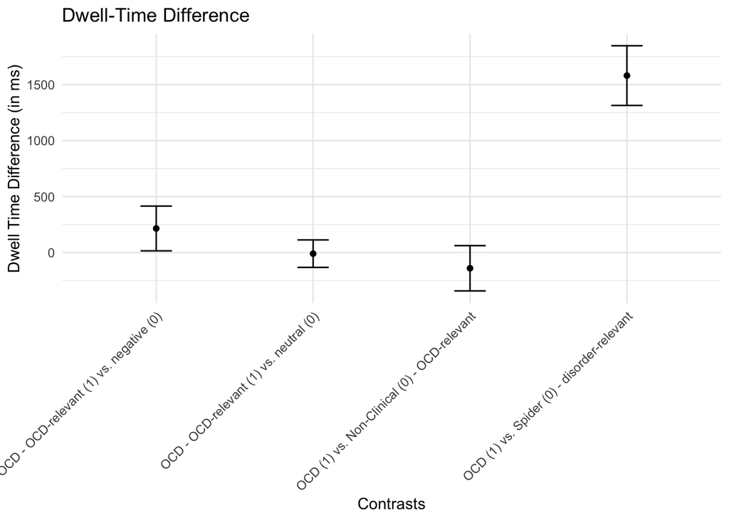

```r
# H1
h1_contrasts$names <- c("OCD - OCD-relevant (1) vs. neutral (0)", "OCD - OCD-relevant (1) vs. negative (0)", "OCD (1) vs. Non-Clinical (0) - OCD-relevant", "OCD (1) vs. Spider (0) - disorder-relevant")

h1_plot <- ggplot(h1_contrasts, aes(x = names, y = Estimate)) +
  geom_point() +
  geom_errorbar(aes(ymin = lower, ymax = upper), width = 0.2) +
  labs(title = "Dwell-Time Difference", y = "Dwell Time Difference (in ms)", x = "Contrasts") +
  theme(axis.text.x = element_text(angle = 45)) +
  theme_minimal() +
  theme(axis.text.x = element_text(angle = 45, hjust = 1)) # Apply 45-degree rotation to x-axis labels

h1_plot
```

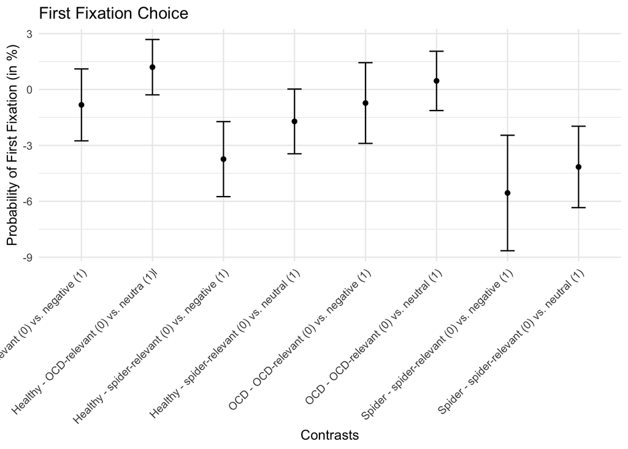

```r
# H2a
h2a_contrasts$names <- c("OCD - OCD-relevant (0) vs. neutral (1)", "OCD - OCD-relevant (0) vs. negative (1)",
                            "Spider - spider-relevant (0) vs. neutral (1)", "Spider - spider-relevant (0) vs. negative (1)",
                            "Healthy - OCD-relevant (0) vs. neutra (1)l", "Healthy - OCD-relevant (0) vs. negative (1)",
                            "Healthy - spider-relevant (0) vs. neutral (1)", "Healthy - spider-relevant (0) vs. negative (1)")

h2a_contrasts <- h2a_contrasts %>%
  dplyr::mutate(Estimate_perc = Estimate*100)
h2a_plot <- ggplot(h2a_contrasts, aes(x = names, y = Estimate_perc)) +
  geom_point() +
  geom_errorbar(aes(ymin = lower*100, ymax = upper*100), width = 0.2) +
  labs(title = "First Fixation Choice", y = "Probability of First Fixation (in %)", x = "Contrasts") +
  theme_minimal() +
  theme(axis.text.x = element_text(angle = 45, hjust = 1))
h2a_plot
```

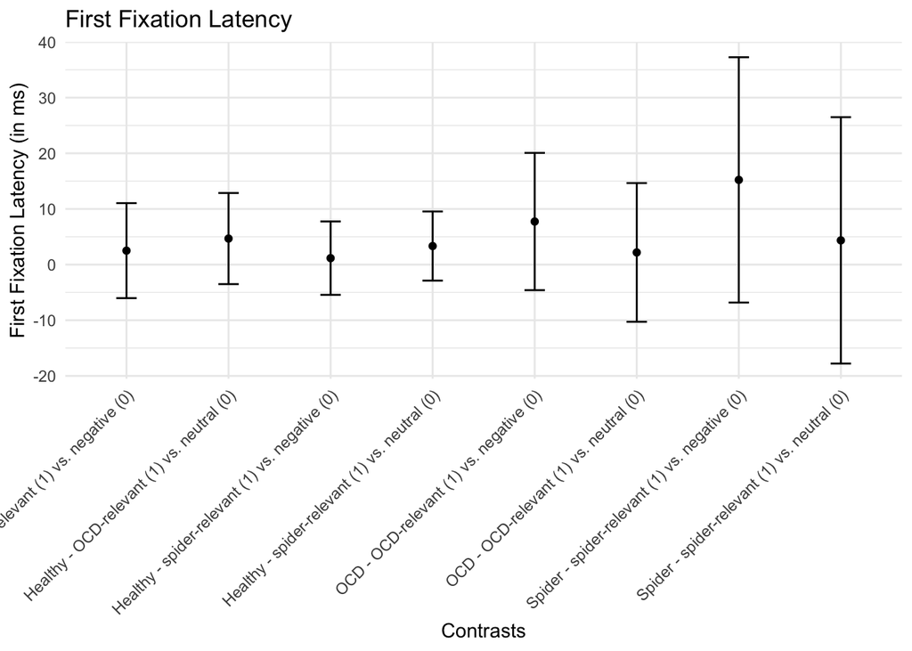

```r
# H2b
h2b_contrasts$names <- c("OCD - OCD-relevant (1) vs. neutral (0)", "OCD - OCD-relevant (1) vs. negative (0)",
                            "Spider - spider-relevant (1) vs. neutral (0)", "Spider - spider-relevant (1) vs. negative (0)",
                            "Healthy - OCD-relevant (1) vs. neutral (0)", "Healthy - OCD-relevant (1) vs. negative (0)",
                            "Healthy - spider-relevant (1) vs. neutral (0)", "Healthy - spider-relevant (1) vs. negative (0)")

h2b_plot <- ggplot(h2b_contrasts, aes(x = names, y = Estimate)) +
  geom_point() +
  geom_errorbar(aes(ymin = lower, ymax = upper), width = 0.2) +
  labs(title = "First Fixation Latency", y = "First Fixation Latency (in ms)", x = "Contrasts") +
  theme_minimal() +
  theme(axis.text.x = element_text(angle = 45, hjust = 1))

h2b_plot
```

# Hypothesis 2b - Sensitivity Analysis: Exclduing 0 Fixations on AOI

```r
data_entrytime_excl0 <- data_entrytime %>%
  dplyr::filter(!c(IA_FIXATION_COUNT_left == 0 | IA_FIXATION_COUNT_right == 0))

#j $assign("form", formula(mlm_dwelltime))
j$assign("jl_data_entrytime_excl0", data_entrytime_excl0)
julia_command("using MixedModels")
```

```r
julia_command("using JellyMe4")
```

```r
# Model 4b: Exclude Triplet and Item
julia_command("h2b_fm_excl_triplet_item_excl0 = @formula(rt ~ group*looked_at + looked_right*group+
              (1 | participant))") # removed random slopes as the model (that was best-fitting) hat a singularity warning - zerocorr() did not remove the warning, removing one RS as well, so both were removed
```

```
## FormulaTerm
## Response:
##   rt(unknown)
## Predictors:
##   group(unknown)
##   looked_at(unknown)
##   looked_right(unknown)
##   group(unknown) & looked_at(unknown)
##   looked_right(unknown) & group(unknown)
##   (participant)->1 | participant
```

```r
julia_command("h2b_fm_excl_triplet_item_excl0 = fit(LinearMixedModel, h2b_fm_excl_triplet_item_excl0, jl_data_entrytime_excl0;contrasts=c_rt)")
```

```
## Linear mixed model fit by maximum likelihood
##  rt ~ 1 + group + looked_at + looked_right + group & looked_at + looked_right & group + (1 | participant)
##     logLik     -2 logLik       AIC         AICc          BIC
##  -140810.1426  281620.2852  281654.2852  281654.3115  281791.2269
##
## Variance components:
##                Column    Variance  Std.Dev.
## participant (Intercept)   4385.0433  66.2197
## Residual                 10199.7677 100.9939
##  Number of obs: 23281; levels of grouping factors: 164
##
##   Fixed-effects parameters:
## ──────────────────────────────────────────────────────────────────────────
##                                         Coef.  Std. Error      z  Pr(>|z|)
## ──────────────────────────────────────────────────────────────────────────
## (Intercept)                         335.236       8.60179  38.97    <1e-99
## group: ocd                            3.07371    12.7999    0.24    0.8102
## group: spider                        48.1419     12.933     3.72    0.0002
## looked_at: neg                        1.36517     2.74376   0.50    0.6188
## looked_at: ocd                        5.77448     3.88114   1.49    0.1368
## looked_at: pho                        1.35417     2.95417   0.46    0.6467
## looked_right: true                    7.38954     1.50537   4.91    <1e-06
## group: ocd & looked_at: neg          -6.42731     3.78697  -1.70    0.0897
## group: spider & looked_at: neg       -7.49968     3.95996  -1.89    0.0582
## group: ocd & looked_at: ocd          -2.96662     6.93265  -0.43    0.6687
## group: spider & looked_at: ocd      -10.1686      5.92845  -1.72    0.0863
## group: ocd & looked_at: pho          -4.65533     4.33432  -1.07    0.2828
## group: spider & looked_at: pho        3.32944    10.8372    0.31    0.7587
## looked_right: true & group: ocd      -2.07044     2.1931   -0.94    0.3451
## looked_right: true & group: spider   -5.08126     2.14844  -2.37    0.0180
## ──────────────────────────────────────────────────────────────────────────
```

```r
h2b_fm_excl_triplet_item_excl0 <- julia_eval("robject(:lmerMod, Tuple([h2b_fm_excl_triplet_item_excl0,jl_data_entrytime_excl0]));",need_return="R")

summary(h2b_fm_excl_triplet_item_excl0)
```

```
## Linear mixed model fit by maximum likelihood . t-tests use Satterthwaite's
##   method [lmerModLmerTest]
## Formula: rt ~ 1 + group + looked_at + looked_right + group:looked_at +
##     looked_right:group + (1 | participant)
##    Data: jellyme4_data
## Control:
## lme4::lmerControl(optCtrl = list(maxeval = 1), optimizer = "nloptwrap",
##     calc.derivs = FALSE, check.nobs.vs.rankZ = "warning", check.nobs.vs.nlev = "warning",
##     check.nlev.gtreq.5 = "ignore", check.nlev.gtr.1 = "warning",
##     check.nobs.vs.nRE = "warning", check.rankX = "message+drop.cols",
##     check.scaleX = "warning", check.formula.LHS = "stop")
##
##       AIC       BIC    logLik  deviance  df.resid
##  281654.3  281791.2 -140810.1  281620.3     23264
##
## Scaled residuals:
##     Min      1Q  Median      3Q     Max
## -5.2732 -0.3927 -0.1392  0.1737 16.3154
##
## Random effects:
##  Groups      Name        Variance Std.Dev.
##  participant (Intercept)  4385     66.22
##  Residual                10200    100.99
## Number of obs: 23281, groups:  participant, 164
##
## Fixed effects:
##                               Estimate Std. Error        df t value Pr(>|t|)
## (Intercept)                    335.236      8.602   163.159  38.973  < 2e-16
## groupocd                         3.074     12.800   161.495   0.240 0.810530
## groupspider                     48.142     12.933   164.617   3.722 0.000271
## looked_atneg                     1.365      2.744 23155.049   0.498 0.618802
## looked_atocd                     5.774      3.881 23165.458   1.488 0.136809
## looked_atpho                     1.354      2.954 23132.922   0.458 0.646674
## looked_rightTRUE                 7.390      1.505 23137.849   4.909 9.23e-07
## groupocd:looked_atneg           -6.427      3.787 23150.337  -1.697 0.089669
## groupspider:looked_atneg        -7.500      3.960 23149.624  -1.894 0.058254
## groupocd:looked_atocd           -2.967      6.933 23147.548  -0.428 0.668713
## groupspider:looked_atocd       -10.169      5.928 23159.701  -1.715 0.086318
## groupocd:looked_atpho           -4.655      4.334 23128.983  -1.074 0.282806
## groupspider:looked_atpho         3.329     10.837 23157.610   0.307 0.758676
## groupocd:looked_rightTRUE       -2.070      2.193 23146.494  -0.944 0.345145
## groupspider:looked_rightTRUE    -5.081      2.148 23264.030  -2.365 0.018034
##
## (Intercept)                  ***
## groupocd
## groupspider                  ***
## looked_atneg
## looked_atocd
## looked_atpho
## looked_rightTRUE             ***
## groupocd:looked_atneg        .
## groupspider:looked_atneg     .
## groupocd:looked_atocd
## groupspider:looked_atocd     .
## groupocd:looked_atpho
## groupspider:looked_atpho
## groupocd:looked_rightTRUE
## groupspider:looked_rightTRUE *
## ---
## Signif. codes:  0 '***' 0.001 '**' 0.01 '*' 0.05 '.' 0.1 ' ' 1
```

```
##
## Correlation matrix not shown by default, as p = 15 > 12.
## Use print(x, correlation=TRUE)  or
##     vcov(x)        if you need it
```

```
## optimizer (LN_BOBYQA) convergence code: 5 (fit with MixedModels.jl)
```

```r
tab_model(h2b_fm_excl_triplet_item_excl0)
```

|  | rt |  |  |
| --- | --- | --- | --- |
| Predictors | Estimates | CI | p |
| (Intercept) | 335.24 | 318.38 – 352.10 | **<0.001** |
| group [ocd] | 3.07 | -22.01 – 28.16 | 0.810 |
| group [spider] | 48.14 | 22.79 – 73.49 | **<0.001** |
| looked at [neg] | 1.37 | -4.01 – 6.74 | 0.619 |
| looked at [ocd] | 5.77 | -1.83 – 13.38 | 0.137 |
| looked at [pho] | 1.35 | -4.44 – 7.14 | 0.647 |
| looked right [TRUE] | 7.39 | 4.44 – 10.34 | **<0.001** |
| group [ocd] × looked at [neg] | -6.43 | -13.85 – 1.00 | 0.090 |
| group [spider] × looked at [neg] | -7.50 | -15.26 – 0.26 | 0.058 |
| group [ocd] × looked at [ocd] | -2.97 | -16.56 – 10.62 | 0.669 |
| group [spider] × looked at [ocd] | -10.17 | -21.79 – 1.45 | 0.086 |
| group [ocd] × looked at [pho] | -4.66 | -13.15 – 3.84 | 0.283 |
| group [spider] × looked at [pho] | 3.33 | -17.91 – 24.57 | 0.759 |
| group [ocd] × looked right [TRUE] | -2.07 | -6.37 – 2.23 | 0.345 |
| group [spider] × looked right [TRUE] | -5.08 | -9.29 – -0.87 | **0.018** |
| Random Effects |  |  |  |
| σ<sup>2</sup> | 10199.77 |  |  |
| τ<sub>00</sub> <sub>participant</sub> | 4385.04 |  |  |
| ICC | 0.30 |  |  |
| N <sub>participant</sub> | 164 |  |  |
| Observations | 23281 |  |  |
| Marginal R<sup>2</sup> / Conditional R<sup>2</sup> | 0.028 / 0.320 |  |  |

```r
# Export
tab_model(h2b_fm_excl_triplet_item_excl0, file = "/Volumes/109-psy-kp-study/044_EYE/06_Results/02_Hauptstudie/MaintenanceBias/summary_h2b_fm_excl_triplet_item_excl0.doc")
```

|  | rt |  |  |
| --- | --- | --- | --- |
| Predictors | Estimates | CI | p |
| (Intercept) | 335.24 | 318.38 – 352.10 | **<0.001** |
| group [ocd] | 3.07 | -22.01 – 28.16 | 0.810 |
| group [spider] | 48.14 | 22.79 – 73.49 | **<0.001** |
| looked at [neg] | 1.37 | -4.01 – 6.74 | 0.619 |
| looked at [ocd] | 5.77 | -1.83 – 13.38 | 0.137 |
| looked at [pho] | 1.35 | -4.44 – 7.14 | 0.647 |
| looked right [TRUE] | 7.39 | 4.44 – 10.34 | **<0.001** |
| group [ocd] × looked at [neg] | -6.43 | -13.85 – 1.00 | 0.090 |
| group [spider] × looked at [neg] | -7.50 | -15.26 – 0.26 | 0.058 |
| group [ocd] × looked at [ocd] | -2.97 | -16.56 – 10.62 | 0.669 |
| group [spider] × looked at [ocd] | -10.17 | -21.79 – 1.45 | 0.086 |
| group [ocd] × looked at [pho] | -4.66 | -13.15 – 3.84 | 0.283 |
| group [spider] × looked at [pho] | 3.33 | -17.91 – 24.57 | 0.759 |
| group [ocd] × looked right [TRUE] | -2.07 | -6.37 – 2.23 | 0.345 |
| group [spider] × looked right [TRUE] | -5.08 | -9.29 – -0.87 | **0.018** |
| Random Effects |  |  |  |
| σ<sup>2</sup> | 10199.77 |  |  |
| τ<sub>00</sub> <sub>participant</sub> | 4385.04 |  |  |
| ICC | 0.30 |  |  |
| N <sub>participant</sub> | 164 |  |  |
| Observations | 23281 |  |  |
| Marginal R<sup>2</sup> / Conditional R<sup>2</sup> | 0.028 / 0.320 |  |  |

```r
# Define the model comparisons to test the specific hypothesis of hypothesis 2
g_h2b_directional_excl0 = (glht(h2b_fm_excl_triplet_item_excl0, (c("looked_atocd + groupocd:looked_atocd <= 0", # Patients with OCD fixate faster on idiosyncratic OCD-relevant material as compared to neutral material (entry time bias within group)
                            "(looked_atocd + groupocd:looked_atocd) - (looked_atneg + groupocd:looked_atneg) <= 0", #Patients with OCD fixate faster on OCD-relevant material as compared to negative material (entry time bias within group)
                            "looked_atpho + groupspider:looked_atpho <= 0", # Patients with spider phobia fixate faster on idiosyncratic spider-relevant material as compared to neutral material (entry time bias within group)
                            "(looked_atpho + groupspider:looked_atpho) - (looked_atneg + groupspider:looked_atneg) <= 0" # Patients with spider phobia fixate faster on spider-relevant material as compared to negative material (entry time bias within group
))))

g_h2b_equality_excl0 = (glht(h2b_fm_excl_triplet_item_excl0, (c("looked_atocd = 0", # Healthy participants will not show a bias towards OCD-relevant stimuli compared to neutral stimuli (entry time bias within healthy group)
                            "looked_atocd - looked_atneg = 0", # Healthy participants will not show a bias towards OCD-relevant stimuli compared to neutral stimuli (entry time bias within healthy group)
                              "looked_atpho = 0", # Healthy participants will not show a bias towards spider-relevant stimuli compared to neutral stimuli (entry time bias within healthy group)
                              "looked_atpho - looked_atneg = 0" # Healthy participants will not show a bias towards spider-relevant stimuli compared to neutral stimuli (entry time bias within healthy group)
))))


# Contest Directional Hypotheses
contest(h2b_fm_excl_triplet_item_excl0,g_h2b_directional_excl0$linfct,joint=FALSE,ddf="Satterthwaite")
```

```
##                                                                                        Estimate
## looked_atocd + groupocd:looked_atocd                                                   2.807851
## (looked_atocd + groupocd:looked_atocd) - (looked_atneg + groupocd:looked_atneg)        7.869990
## looked_atpho + groupspider:looked_atpho                                                4.683612
## (looked_atpho + groupspider:looked_atpho) - (looked_atneg + groupspider:looked_atneg) 10.818115
##                                                                                       Std. Error
## looked_atocd + groupocd:looked_atocd                                                    5.744418
## (looked_atocd + groupocd:looked_atocd) - (looked_atneg + groupocd:looked_atneg)         5.686368
## looked_atpho + groupspider:looked_atpho                                                10.426806
## (looked_atpho + groupspider:looked_atpho) - (looked_atneg + groupspider:looked_atneg)  10.344007
##                                                                                             df
## looked_atocd + groupocd:looked_atocd                                                  23138.95
## (looked_atocd + groupocd:looked_atocd) - (looked_atneg + groupocd:looked_atneg)       23139.19
## looked_atpho + groupspider:looked_atpho                                               23159.50
## (looked_atpho + groupspider:looked_atpho) - (looked_atneg + groupspider:looked_atneg) 23157.19
##                                                                                         t value
## looked_atocd + groupocd:looked_atocd                                                  0.4887964
## (looked_atocd + groupocd:looked_atocd) - (looked_atneg + groupocd:looked_atneg)       1.3840099
## looked_atpho + groupspider:looked_atpho                                               0.4491896
## (looked_atpho + groupspider:looked_atpho) - (looked_atneg + groupspider:looked_atneg) 1.0458341
##                                                                                            lower
## looked_atocd + groupocd:looked_atocd                                                   -8.451591
## (looked_atocd + groupocd:looked_atocd) - (looked_atneg + groupocd:looked_atneg)        -3.275670
## looked_atpho + groupspider:looked_atpho                                               -15.753620
## (looked_atpho + groupspider:looked_atpho) - (looked_atneg + groupspider:looked_atneg)  -9.456826
##                                                                                          upper
## looked_atocd + groupocd:looked_atocd                                                  14.06729
## (looked_atocd + groupocd:looked_atocd) - (looked_atneg + groupocd:looked_atneg)       19.01565
## looked_atpho + groupspider:looked_atpho                                               25.12084
## (looked_atpho + groupspider:looked_atpho) - (looked_atneg + groupspider:looked_atneg) 31.09306
##                                                                                        Pr(>|t|)
## looked_atocd + groupocd:looked_atocd                                                  0.6249905
## (looked_atocd + groupocd:looked_atocd) - (looked_atneg + groupocd:looked_atneg)       0.1663688
## looked_atpho + groupspider:looked_atpho                                               0.6532991
## (looked_atpho + groupspider:looked_atpho) - (looked_atneg + groupspider:looked_atneg) 0.2956485
```

```r
# Contest Equality Hypotheses
contest(h2b_fm_excl_triplet_item_excl0,g_h2b_equality_excl0$linfct,joint=FALSE,ddf="Satterthwaite")
```

```
##                                Estimate Std. Error       df      t value
## looked_atocd                 5.77447590   3.881141 23165.46  1.487829419
## looked_atocd - looked_atneg  4.40930333   4.056801 23191.45  1.086891668
## looked_atpho                 1.35416945   2.954166 23132.92  0.458393096
## looked_atpho - looked_atneg -0.01100313   3.142761 23170.42 -0.003501102
##                                 lower     upper  Pr(>|t|)
## looked_atocd                -1.832818 13.381770 0.1368095
## looked_atocd - looked_atneg -3.542296 12.360902 0.2770960
## looked_atpho                -4.436193  7.144532 0.6466744
## looked_atpho - looked_atneg -6.171023  6.149016 0.9972066
```

```r
# Create Data Tables
rownames_h2b_contrast_directional_excl0 <- c("looked_atocd + groupocd:looked_atocd",
                                       "(looked_atocd + groupocd:looked_atocd) - (looked_atneg + groupocd:looked_atneg)",
                                       "looked_atpho + groupspider:looked_atpho",
                                       "(looked_atpho + groupspider:looked_atpho) - (looked_atneg + groupspider:looked_atneg)")
rownames_h2b_contrast_equality_excl0 <- c("looked_atocd",
                                    "looked_atocd - looked_atneg",
                                    "looked_atpho",
                                    "looked_atpho - looked_atneg")

h2b_contrasts_directional_excl0 <- as.data.table(contest(h2b_fm_excl_triplet_item_excl0,g_h2b_directional_excl0$linfct,joint=FALSE,ddf="Satterthwaite"))
h2b_contrasts_directional_excl0 <- h2b_contrasts_directional_excl0 %>%
  dplyr::mutate(contrast = rownames_h2b_contrast_directional_excl0) %>%
  dplyr::relocate(contrast, .before = Estimate)

h2b_contrasts_equality_excl0 <- as.data.table(contest(h2b_fm_excl_triplet_item_excl0,g_h2b_equality_excl0$linfct,joint=FALSE,ddf="Satterthwaite"))
h2b_contrasts_equality_excl0 <- h2b_contrasts_equality_excl0 %>%
  dplyr::mutate(contrast = rownames_h2b_contrast_equality_excl0) %>%
  dplyr::relocate(contrast, .before = Estimate)

h2b_contrasts_excl0 <- full_join(h2b_contrasts_directional_excl0, h2b_contrasts_equality_excl0)
```

[output not shown]

```r
datatable(h2b_contrasts_excl0)
```

|  | contrast | Estimate | Std. Error | df | t value | lower | upper | Pr(>\|t\|) |
| --- | --- | --- | --- | --- | --- | --- | --- | --- |
| 1 | looked_atocd + groupocd:looked_atocd | 2.807851125914633 | 5.74441830692914 | 23138.95096270487 | 0.4887964239177524 | -8.451590832227032 | 14.0672930840563 | 0.624990462626238 |
| 2 | (looked_atocd + groupocd:looked_atocd) - (looked_atneg + groupocd:looked_atneg) | 7.869989851126601 | 5.68636837925949 | 23139.18963286784 | 1.384009850616022 | -3.275670381713441 | 19.01565008396664 | 0.1663687870908917 |
| 3 | looked_atpho + groupspider:looked_atpho | 4.68361240804552 | 10.42680586200175 | 23159.49599604772 | 0.4491895667794045 | -15.75361964769909 | 25.12084446379013 | 0.6532991163906785 |
| 4 | (looked_atpho + groupspider:looked_atpho) - (looked_atneg + groupspider:looked_atneg) | 10.81811541397974 | 10.34400702364534 | 23157.19320092475 | 1.045834113342213 | -9.456825524321415 | 31.0930563522809 | 0.2956485443970848 |
| 5 | looked_atocd | 5.774475900474384 | 3.881141095939364 | 23165.45809066574 | 1.487829418651107 | -1.832818337246356 | 13.38177013819512 | 0.1368094965525951 |
| 6 | looked_atocd - looked_atneg | 4.409303328655446 | 4.05680111215162 | 23191.44706106405 | 1.086891668277242 | -3.542295738247669 | 12.36090239555856 | 0.2770959850871879 |
| 7 | looked_atpho | 1.354169446080527 | 2.954166321274667 | 23132.92182512891 | 0.4583930959906917 | -4.436193112032667 | 7.144532004193721 | 0.6466743570163233 |
| 8 | looked_atpho - looked_atneg | -0.01100312573841 | 3.142760629396272 | 23170.4184195167 | -0.003501102067873275 | -6.171022555107321 | 6.1490163036305 | 0.9972065605617337 |

```r
# Export
write_xlsx(h2b_contrasts_excl0, "/Volumes/109-psy-kp-study/044_EYE/06_Results/02_Hauptstudie/VigilanceBias/h2b_contrasts_excl0.xlsx")
```

Could replicate results of total dataset.